# Developing a cryopreservation protocol for the forest-forming seaweed *Phyllospora comosa* as a tool for restoration

Catalina A. Musrri

2025-10-10

## Load packages

*Before loading the packages install them using *install()**

```r
library(summarytools)
library(tidyr)
library(dplyr)
library(readr)
library(vegan)
library(patchwork)
library(ggplot2)
library(pander)
library(lme4)
library(emmeans)
library(wesanderson)
library(corrplot)
library(outliers)
library(MuMIn)
library("viridis")
library(ggbreak)
library(scales)
```

*The following sections include the steps for data handling, visualisation and statistical analyses conducted for experiments 1-7*

# **1.** Sperm freezing trial

## **1a)** Import data

```r
Sperm_freezing <- read.csv("Data_cryo/Sperm_freezing_trial1.csv")
```

## **1b)** Data structure and summary

1. Check structure

```r
str(Sperm_freezing)
```

```
## 'data.frame':    119 obs. of  14 variables:
##  $ Male         : int  4 4 4 4 4 4 4 4 4 4 ...
##  $ Repeat       : int  1 1 1 2 2 2 1 2 2 1 ...
##  $ CPA          : chr  "Control" "DMSO" "DMSO" "DMSO" ...
##  $ Conc         : int  NA 5 15 5 10 10 15 5 15 10 ...
##  $ Straws       : int  NA 1 2 3 4 5 6 7 8 9 ...
##  $ Treatment    : chr  "Control" "DMSO 5%" "DMSO 15%" "DMSO 5%" ...
##  $ Freezing_rate: chr  "Medium" "Medium" "Medium" "Medium" ...
##  $ Rate         : num  15.1 NA NA NA NA ...
##  $ Motile_number: int  NA 2 6 2 2 5 0 0 0 5 ...
##  $ Motility     : num  62.2 11.76 22.22 9.09 9.09 ...
##  $ Density_M    : num  12.84 0.4 0.49 0.52 0.52 ...
##  $ Density      : int  12840000 400000 490000 520000 520000 460000 430000 90000 330000 780000 ...
##  $ X            : logi  NA NA NA NA NA NA ...
##  $ Count        : int  325 17 27 22 22 25 18 4 11 36 ...
```

2. Average duplicates

```r
Sperm_freezing1 <- Sperm_freezing %>%
  group_by(Male, Treatment, Freezing_rate)%>%
  summarise(Density = mean(Density), Motility = mean(Motility))
```

3. Calculate mean by treatment and freezing rate

```r
Sperm_mean <- Sperm_freezing1 %>%
  group_by (Treatment, Freezing_rate)  %>%
  summarise(Density_mean = mean(Density), n = n(), sd_conc = sd(Density), se_conc = sd_conc/sqrt(n), Motility_mean = mean(Motility), sd_motility = sd(Motility), se = sd_motility/sqrt(n))
```

## **1c)** Visualise patterns

Set general theme

```r
Theme1 <- theme_bw() +
    theme(panel.grid.major = element_line(colour = "white"),
          panel.grid.minor = element_line(colour = "white"), axis.text.y = element_text(size = 12, face="bold"), axis.title.y = element_text(size = 12, face="bold"), axis.text.x = element_text(size = 12, face="bold"), axis.title.x =     element_text(size = 12, face="bold"), plot.title=element_text(hjust=0.95, vjust=-8, size=12, face="bold"), axis.ticks = element_blank())
```

### i. Sperm concentration

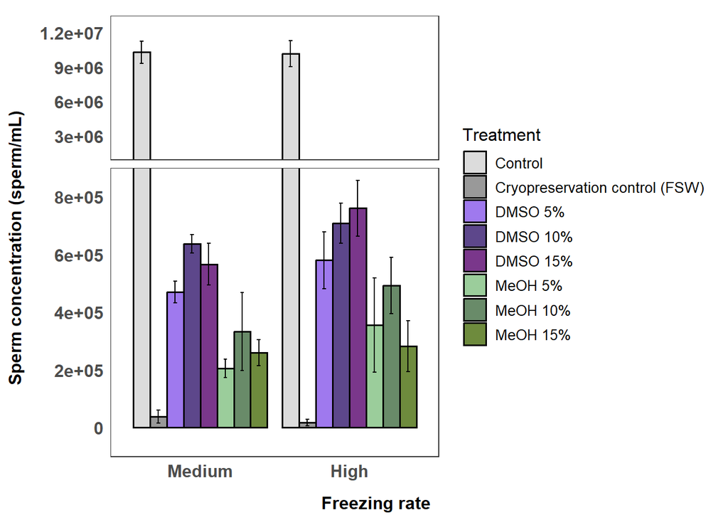

```r
Sperm_mean$Treatment <- factor(Sperm_mean$Treatment, levels = c("Control", "Cryopreservation control (FSW)", "DMSO 5%", "DMSO 10%", "DMSO 15%", "MeOH 5%", "MeOH 10%", "MeOH 15%"))
Sperm_mean$Freezing_rate <- factor(Sperm_mean$Freezing_rate, levels = c("Medium", "High"))

plot <- Sperm_mean %>%
ggplot(aes(x= Freezing_rate, y= Density_mean, fill = Treatment)) +
  geom_bar(stat="identity", color="black",
           position=position_dodge(), linewidth = 0.6) +
 geom_errorbar(aes(ymin=Density_mean-se_conc, ymax=Density_mean+se_conc), width=.2, position=position_dodge(0.9)) +
Theme1 +
labs( y="Sperm concentration (sperm/mL)", x="Freezing rate")   +
  scale_fill_viridis(discrete = TRUE) +
  theme(legend.key.size = unit(0.6, 'cm'), #change legend key size
        legend.key.height = unit(0.6, 'cm'), #change legend key height
        legend.key.width = unit(0.6, 'cm'), #change legend key width
        legend.title = element_text(size=12), #change legend title font size
        legend.text = element_text(size=10)) #change legend text font size


p1 <- plot +scale_y_cut(breaks=c(900000), which=c(2, 1), scales=c(4, 2)) +
  scale_y_continuous(
    breaks = c(seq(0, 900000, by = 200000), seq(3000000, 12000000, by = 3000000)), limits = c(-100000, 13500000),  # Adjust tick marks
    labels = function(x) ifelse(x < 1000000, x, x)             # Customize labels
  )

p1 + scale_fill_manual(
    values = c("DMSO 10%" = "mediumpurple4", "DMSO 15%" = "mediumorchid4", "DMSO 5%" = "mediumpurple2","MeOH 10%" = "darkseagreen4","MeOH 5%" = "darkseagreen3","MeOH 15%" = "darkolivegreen4","Control" = "gainsboro", "Cryopreservation control (FSW)" = "gray60"))
```

```r
ggsave("Density_FT1.jpeg", width = 17, height = 8, units = "cm")
```

### ii. Sperm motility

```r
plot <- Sperm_mean   %>%
ggplot(aes(x= Freezing_rate, y= Motility_mean, fill = Treatment)) +
  geom_bar(stat="identity", color="black",
           position=position_dodge(), linewidth = 0.6) +
 geom_errorbar(aes(ymin=Motility_mean-se, ymax=Motility_mean+se), width=.2, position=position_dodge(0.9)) +
Theme1 +
labs( y="Motile sperm (%)", x="Freezing rate")
theme(strip.text.x = element_text(size = 12)) +
  theme(legend.key.size = unit(0.6, 'cm'), #change legend key size
        legend.key.height = unit(0.6, 'cm'), #change legend key height
        legend.key.width = unit(0.6, 'cm'), #change legend key width
        legend.title = element_text(size=12), #change legend title font size
        legend.text = element_text(size=10)) #change legend text font size
```

[output not shown]

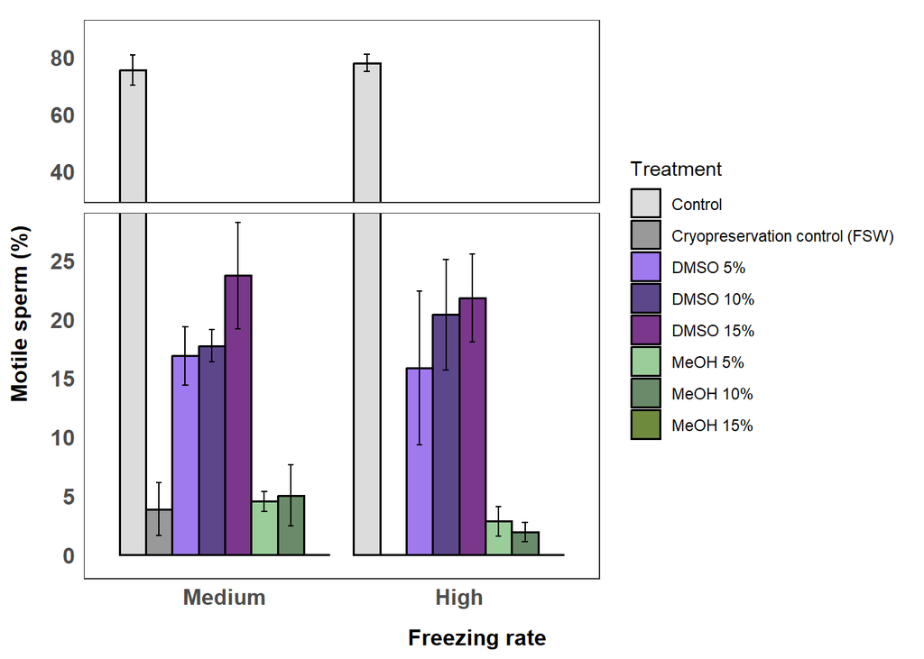

```r
p1 <- plot +scale_y_cut(breaks=c(29), which=c(2, 1), scales=c(4, 2)) +
  scale_y_continuous(
    breaks = c(seq(0, 25, by = 5), seq(40, 80, by = 20)), limits = c(-2, 93),  # Adjust tick marks
    labels = function(x) ifelse(x < 1, x, x)             # Customize labels
  )

p1 + scale_fill_manual(
    values = c("DMSO 10%" = "mediumpurple4", "DMSO 15%" = "mediumorchid4", "DMSO 5%" = "mediumpurple2","MeOH 10%" = "darkseagreen4","MeOH 5%" = "darkseagreen3","MeOH 15%" = "darkolivegreen4","Control" = "gainsboro", "Cryopreservation control (FSW)" = "gray60"))
```

```r
ggsave("Motility_FT1.jpeg", width = 15.5, height = 8.5, units = "cm")
```

## **1d)** Statistical analyses

### i. Sperm concentration

```r
Sperm_freezing1$Male <- as.factor(Sperm_freezing1$Male)

model <- lmer(sqrt(Density) ~ Treatment*Freezing_rate + (1|Male), data = Sperm_freezing1)
summary(model)
```

```
## Linear mixed model fit by REML ['lmerMod']
## Formula: sqrt(Density) ~ Treatment * Freezing_rate + (1 | Male)
##    Data: Sperm_freezing1
##
## REML criterion at convergence: 655.7
##
## Scaled residuals:
##     Min      1Q  Median      3Q     Max
## -2.7045 -0.4643 -0.0270  0.4558  2.1058
##
## Random effects:
##  Groups   Name        Variance Std.Dev.
##  Male     (Intercept)  7749     88.03
##  Residual             28438    168.63
## Number of obs: 64, groups:  Male, 4
##
## Fixed effects:
##                                                             Estimate Std. Error
## (Intercept)                                                  3172.36      95.11
## TreatmentCryopreservation control (FSW)                     -3081.14     119.24
## TreatmentDMSO 10%                                           -2333.73     119.24
## TreatmentDMSO 15%                                           -2306.33     119.24
## TreatmentDMSO 5%                                            -2418.46     119.24
## TreatmentMeOH 10%                                           -2481.31     119.24
## TreatmentMeOH 15%                                           -2667.60     119.24
## TreatmentMeOH 5%                                            -2619.95     119.24
## Freezing_rateMedium                                            26.58     119.24
## TreatmentCryopreservation control (FSW):Freezing_rateMedium    21.23     168.63
## TreatmentDMSO 10%:Freezing_rateMedium                         -68.26     168.63
## TreatmentDMSO 15%:Freezing_rateMedium                        -145.07     168.63
## TreatmentDMSO 5%:Freezing_rateMedium                          -96.49     168.63
## TreatmentMeOH 10%:Freezing_rateMedium                        -225.87     168.63
## TreatmentMeOH 15%:Freezing_rateMedium                         -27.00     168.63
## TreatmentMeOH 5%:Freezing_rateMedium                         -130.51     168.63
##                                                             t value
## (Intercept)                                                  33.353
## TreatmentCryopreservation control (FSW)                     -25.839
## TreatmentDMSO 10%                                           -19.571
## TreatmentDMSO 15%                                           -19.341
## TreatmentDMSO 5%                                            -20.282
## TreatmentMeOH 10%                                           -20.809
## TreatmentMeOH 15%                                           -22.371
## TreatmentMeOH 5%                                            -21.972
## Freezing_rateMedium                                           0.223
## TreatmentCryopreservation control (FSW):Freezing_rateMedium   0.126
## TreatmentDMSO 10%:Freezing_rateMedium                        -0.405
## TreatmentDMSO 15%:Freezing_rateMedium                        -0.860
## TreatmentDMSO 5%:Freezing_rateMedium                         -0.572
## TreatmentMeOH 10%:Freezing_rateMedium                        -1.339
## TreatmentMeOH 15%:Freezing_rateMedium                        -0.160
## TreatmentMeOH 5%:Freezing_rateMedium                         -0.774
```

```
##
## Correlation matrix not shown by default, as p = 16 > 12.
## Use print(x, correlation=TRUE)  or
##     vcov(x)        if you need it
```

```r
car::Anova(model)
```

```
## Analysis of Deviance Table (Type II Wald chisquare tests)
##
## Response: sqrt(Density)
##                             Chisq Df Pr(>Chisq)
## Treatment               1772.1616  7     <2e-16 ***
## Freezing_rate              1.8551  1     0.1732
## Treatment:Freezing_rate    3.3619  7     0.8496
## ---
## Signif. codes:  0 '***' 0.001 '**' 0.01 '*' 0.05 '.' 0.1 ' ' 1
```

Contrasts:

```r
emmeans(model, specs = pairwise ~ Treatment, type = "response", adjust = "none")
```

```
## NOTE: Results may be misleading due to involvement in interactions
```

```
## $emmeans
##  Treatment                      response     SE   df lower.CL upper.CL
##  Control                        10148333 472164 14.3  9162942 11184038
##  Cryopreservation control (FSW)    13254  17064 14.3        0    74931
##  DMSO 10%                         668761 121208 14.3   434503   953333
##  DMSO 15%                         650895 119578 14.3   420126   931978
##  DMSO 5%                          516876 106559 14.3   313971   770094
##  MeOH 10%                         349758  87656 14.3   187311   562520
##  MeOH 15%                         254561  74781 14.3   119668   439768
##  MeOH 5%                          250438  74173 14.3   116846   434343
##
## Results are averaged over the levels of: Freezing_rate
## Degrees-of-freedom method: kenward-roger
## Confidence level used: 0.95
## Intervals are back-transformed from the sqrt scale
##
## $contrasts
##  contrast                                  estimate   SE df t.ratio p.value
##  Control - Cryopreservation control (FSW)    3070.5 84.3 45  36.416  <.0001
##  Control - DMSO 10%                          2367.9 84.3 45  28.083  <.0001
##  Control - DMSO 15%                          2378.9 84.3 45  28.213  <.0001
##  Control - DMSO 5%                           2466.7 84.3 45  29.255  <.0001
##  Control - MeOH 10%                          2594.2 84.3 45  30.768  <.0001
##  Control - MeOH 15%                          2681.1 84.3 45  31.798  <.0001
##  Control - MeOH 5%                           2685.2 84.3 45  31.846  <.0001
##  Cryopreservation control (FSW) - DMSO 10%   -702.7 84.3 45  -8.333  <.0001
##  Cryopreservation control (FSW) - DMSO 15%   -691.7 84.3 45  -8.203  <.0001
##  Cryopreservation control (FSW) - DMSO 5%    -603.8 84.3 45  -7.161  <.0001
##  Cryopreservation control (FSW) - MeOH 10%   -476.3 84.3 45  -5.649  <.0001
##  Cryopreservation control (FSW) - MeOH 15%   -389.4 84.3 45  -4.618  <.0001
##  Cryopreservation control (FSW) - MeOH 5%    -385.3 84.3 45  -4.570  <.0001
##  DMSO 10% - DMSO 15%                           11.0 84.3 45   0.130  0.8968
##  DMSO 10% - DMSO 5%                            98.8 84.3 45   1.172  0.2473
##  DMSO 10% - MeOH 10%                          226.4 84.3 45   2.685  0.0101
##  DMSO 10% - MeOH 15%                          313.2 84.3 45   3.715  0.0006
##  DMSO 10% - MeOH 5%                           317.3 84.3 45   3.764  0.0005
##  DMSO 15% - DMSO 5%                            87.8 84.3 45   1.042  0.3031
##  DMSO 15% - MeOH 10%                          215.4 84.3 45   2.554  0.0141
##  DMSO 15% - MeOH 15%                          302.2 84.3 45   3.585  0.0008
##  DMSO 15% - MeOH 5%                           306.3 84.3 45   3.633  0.0007
##  DMSO 5% - MeOH 10%                           127.5 84.3 45   1.513  0.1374
##  DMSO 5% - MeOH 15%                           214.4 84.3 45   2.543  0.0145
##  DMSO 5% - MeOH 5%                            218.5 84.3 45   2.591  0.0128
##  MeOH 10% - MeOH 15%                           86.9 84.3 45   1.030  0.3084
##  MeOH 10% - MeOH 5%                            91.0 84.3 45   1.079  0.2864
##  MeOH 15% - MeOH 5%                             4.1 84.3 45   0.049  0.9614
##
## Results are averaged over the levels of: Freezing_rate
## Note: contrasts are still on the sqrt scale
## Degrees-of-freedom method: kenward-roger
```

Check model assumptions:

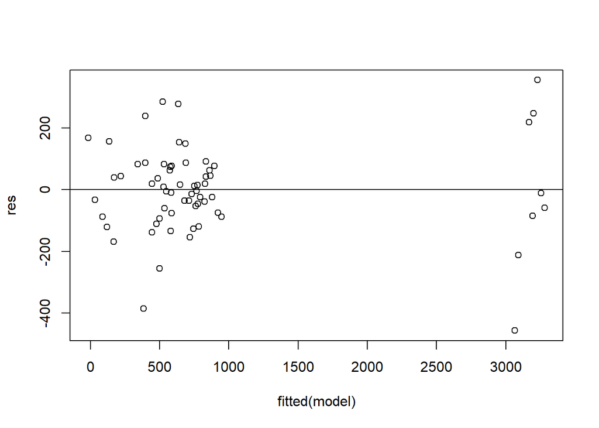

```r
res <- resid(model)

#produce residual vs. fitted plot
plot(fitted(model), res)

#add a horizontal line at 0
abline(0,0)
```

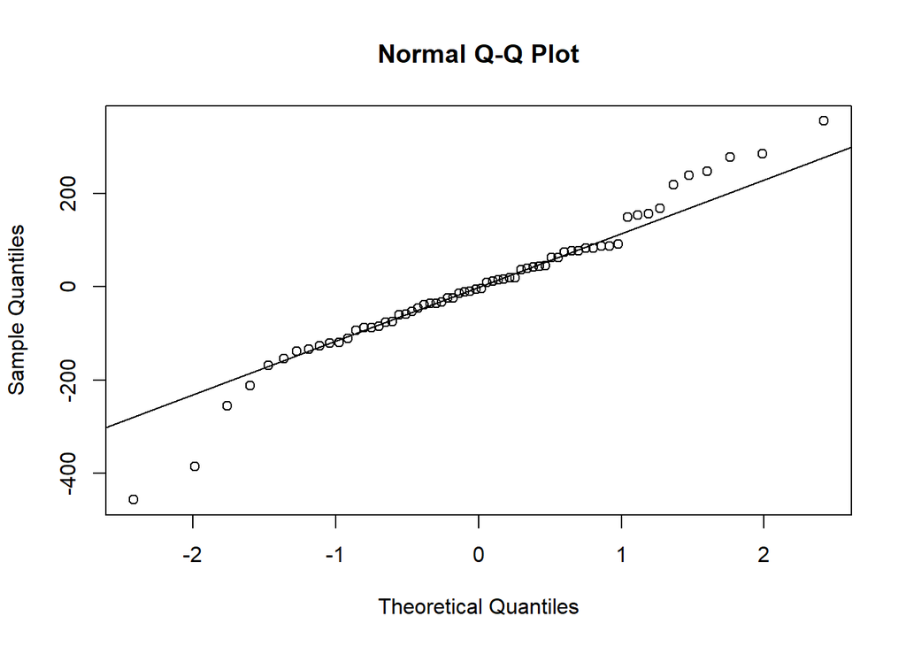

```r
#create Q-Q plot for residuals
qqnorm(res)

#add a straight diagonal line to the plot
qqline(res)
```

### ii. Sperm motility

```r
model_mot <- lmer(sqrt(Motility) ~ Treatment*Freezing_rate + (1|Male), data = Sperm_freezing1)
```

```
## boundary (singular) fit: see help('isSingular')
```

```r
summary(model_mot)
```

```
## Linear mixed model fit by REML ['lmerMod']
## Formula: sqrt(Motility) ~ Treatment * Freezing_rate + (1 | Male)
##    Data: Sperm_freezing1
##
## REML criterion at convergence: 149.8
##
## Scaled residuals:
##     Min      1Q  Median      3Q     Max
## -2.1047 -0.4320  0.0000  0.4956  2.1990
##
## Random effects:
##  Groups   Name        Variance  Std.Dev.
##  Male     (Intercept) 2.850e-22 1.688e-11
##  Residual             8.352e-01 9.139e-01
## Number of obs: 64, groups:  Male, 4
##
## Fixed effects:
##                                                             Estimate Std. Error
## (Intercept)                                                  8.82088    0.45695
## TreatmentCryopreservation control (FSW)                     -8.82088    0.64622
## TreatmentDMSO 10%                                           -4.39023    0.64622
## TreatmentDMSO 15%                                           -4.20139    0.64622
## TreatmentDMSO 5%                                            -5.12963    0.64622
## TreatmentMeOH 10%                                           -7.63891    0.64622
## TreatmentMeOH 15%                                           -8.82088    0.64622
## TreatmentMeOH 5%                                            -7.39856    0.64622
## Freezing_rateMedium                                         -0.15452    0.64622
## TreatmentCryopreservation control (FSW):Freezing_rateMedium  1.54437    0.91389
## TreatmentDMSO 10%:Freezing_rateMedium                       -0.07432    0.91389
## TreatmentDMSO 15%:Freezing_rateMedium                        0.32335    0.91389
## TreatmentDMSO 5%:Freezing_rateMedium                         0.53471    0.91389
## TreatmentMeOH 10%:Freezing_rateMedium                        0.79716    0.91389
## TreatmentMeOH 15%:Freezing_rateMedium                        0.15452    0.91389
## TreatmentMeOH 5%:Freezing_rateMedium                         0.83452    0.91389
##                                                             t value
## (Intercept)                                                  19.304
## TreatmentCryopreservation control (FSW)                     -13.650
## TreatmentDMSO 10%                                            -6.794
## TreatmentDMSO 15%                                            -6.501
## TreatmentDMSO 5%                                             -7.938
## TreatmentMeOH 10%                                           -11.821
## TreatmentMeOH 15%                                           -13.650
## TreatmentMeOH 5%                                            -11.449
## Freezing_rateMedium                                          -0.239
## TreatmentCryopreservation control (FSW):Freezing_rateMedium   1.690
## TreatmentDMSO 10%:Freezing_rateMedium                        -0.081
## TreatmentDMSO 15%:Freezing_rateMedium                         0.354
## TreatmentDMSO 5%:Freezing_rateMedium                          0.585
## TreatmentMeOH 10%:Freezing_rateMedium                         0.872
## TreatmentMeOH 15%:Freezing_rateMedium                         0.169
## TreatmentMeOH 5%:Freezing_rateMedium                          0.913
```

```
##
## Correlation matrix not shown by default, as p = 16 > 12.
## Use print(x, correlation=TRUE)  or
##     vcov(x)        if you need it
```

```
## optimizer (nloptwrap) convergence code: 0 (OK)
## boundary (singular) fit: see help('isSingular')
```

```r
car::Anova(model_mot)
```

```
## Analysis of Deviance Table (Type II Wald chisquare tests)
##
## Response: sqrt(Motility)
##                            Chisq Df Pr(>Chisq)
## Treatment               537.9783  7     <2e-16 ***
## Freezing_rate             2.4795  1     0.1153
## Treatment:Freezing_rate   4.8393  7     0.6796
## ---
## Signif. codes:  0 '***' 0.001 '**' 0.01 '*' 0.05 '.' 0.1 ' ' 1
```

Contrasts:

```r
emmeans(model_mot, specs = pairwise ~ Treatment, type = "response", adjust = "none")
```

```
## NOTE: Results may be misleading due to involvement in interactions
```

```
## $emmeans
##  Treatment                      response    SE df lower.CL upper.CL
##  Control                          76.451 5.650 45 65.49402   88.255
##  Cryopreservation control (FSW)    0.483 0.449 45  0.00195    1.811
##  DMSO 10%                         18.630 2.789 45 13.43549   24.671
##  DMSO 15%                         22.127 3.040 45 16.42781   28.673
##  DMSO 5%                          15.065 2.508 45 10.43652   20.540
##  MeOH 10%                          2.260 0.971 45  0.72678    4.640
##  MeOH 15%                          0.000 0.000 45  0.00000    0.424
##  MeOH 5%                           3.106 1.139 45  1.23551    5.823
##
## Results are averaged over the levels of: Freezing_rate
## Degrees-of-freedom method: kenward-roger
## Confidence level used: 0.95
## Intervals are back-transformed from the sqrt scale
##
## $contrasts
##  contrast                                  estimate    SE df t.ratio p.value
##  Control - Cryopreservation control (FSW)     8.049 0.457 45  17.614  <.0001
##  Control - DMSO 10%                           4.427 0.457 45   9.689  <.0001
##  Control - DMSO 15%                           4.040 0.457 45   8.841  <.0001
##  Control - DMSO 5%                            4.862 0.457 45  10.641  <.0001
##  Control - MeOH 10%                           7.240 0.457 45  15.845  <.0001
##  Control - MeOH 15%                           8.744 0.457 45  19.135  <.0001
##  Control - MeOH 5%                            6.981 0.457 45  15.278  <.0001
##  Cryopreservation control (FSW) - DMSO 10%   -3.621 0.457 45  -7.925  <.0001
##  Cryopreservation control (FSW) - DMSO 15%   -4.009 0.457 45  -8.773  <.0001
##  Cryopreservation control (FSW) - DMSO 5%    -3.186 0.457 45  -6.973  <.0001
##  Cryopreservation control (FSW) - MeOH 10%   -0.808 0.457 45  -1.769  0.0837
##  Cryopreservation control (FSW) - MeOH 15%    0.695 0.457 45   1.521  0.1353
##  Cryopreservation control (FSW) - MeOH 5%    -1.067 0.457 45  -2.336  0.0240
##  DMSO 10% - DMSO 15%                         -0.388 0.457 45  -0.848  0.4007
##  DMSO 10% - DMSO 5%                           0.435 0.457 45   0.952  0.3463
##  DMSO 10% - MeOH 10%                          2.813 0.457 45   6.156  <.0001
##  DMSO 10% - MeOH 15%                          4.316 0.457 45   9.446  <.0001
##  DMSO 10% - MeOH 5%                           2.554 0.457 45   5.589  <.0001
##  DMSO 15% - DMSO 5%                           0.823 0.457 45   1.800  0.0785
##  DMSO 15% - MeOH 10%                          3.201 0.457 45   7.004  <.0001
##  DMSO 15% - MeOH 15%                          4.704 0.457 45  10.294  <.0001
##  DMSO 15% - MeOH 5%                           2.942 0.457 45   6.438  <.0001
##  DMSO 5% - MeOH 10%                           2.378 0.457 45   5.204  <.0001
##  DMSO 5% - MeOH 15%                           3.881 0.457 45   8.494  <.0001
##  DMSO 5% - MeOH 5%                            2.119 0.457 45   4.637  <.0001
##  MeOH 10% - MeOH 15%                          1.503 0.457 45   3.290  0.0020
##  MeOH 10% - MeOH 5%                          -0.259 0.457 45  -0.567  0.5736
##  MeOH 15% - MeOH 5%                          -1.762 0.457 45  -3.857  0.0004
##
## Results are averaged over the levels of: Freezing_rate
## Note: contrasts are still on the sqrt scale
## Degrees-of-freedom method: kenward-roger
```

Check model assumptions:

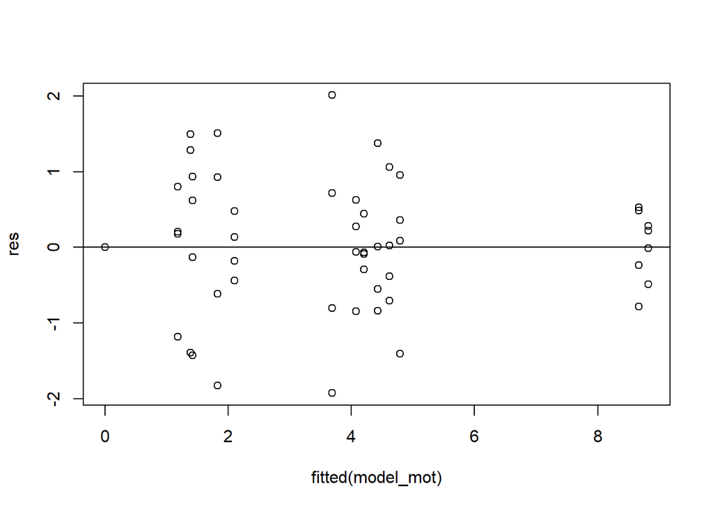

```r
res <- resid(model_mot)

#produce residual vs. fitted plot
plot(fitted(model_mot), res)

#add a horizontal line at 0
abline(0,0)
```

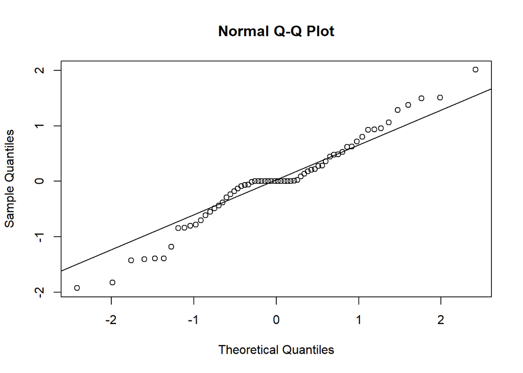

```r
#create Q-Q plot for residuals
qqnorm(res)

#add a straight diagonal line to the plot
qqline(res)
```

# **2.** Experiment 1: Sperm cryoprotectant toxicity

## **2a)** Import data

```r
Sperm_Toxicity <- read.csv("Data_cryo/Sperm_toxicity_4oct.csv")
```

## **2b)** Data structure and summary

1. Check structure

```r
str(Sperm_Toxicity)
```

```
## 'data.frame':    50 obs. of  13 variables:
##  $ Male         : int  1 1 1 1 1 1 1 1 1 1 ...
##  $ CPA          : chr  "Control" "PG" "Gly" "EG" ...
##  $ Conc         : int  0 15 15 10 10 0 10 15 10 15 ...
##  $ Equilibration: int  0 10 10 10 10 10 10 10 10 10 ...
##  $ Treatment    : chr  "Control" "PG 15%" "Gly 15%" "EG 10%" ...
##  $ Tube         : int  NA 1 2 3 4 5 6 7 8 9 ...
##  $ Density_MmL  : num  6.08 2.47 0.77 1.16 2.07 1.66 0.95 1.29 1.71 1.52 ...
##  $ Density      : num  6080000 2470000 770000 1160000 2070000 1660000 950000 1290000 1710000 1520000 ...
##  $ Motility     : int  3 1 1 2 2 2 1 1 2 2 ...
##  $ Speed        : int  3 1 2 3 3 3 2 1 2 2 ...
##  $ Number       : num  231 100 52 49 96 63 44 60 72 64 ...
##  $ Germlings    : int  NA NA NA NA NA NA 3 NA NA NA ...
##  $ Comment      : chr  "" "" "" "" ...
```

```r
SpermTox_mean <- Sperm_Toxicity %>%
  group_by (Treatment)  %>%
  summarise(Density_mean = mean(Density), n = n(), sd_conc = sd(Density), se_conc = sd_conc/sqrt(n), Motility_mean = mean(Motility), sd_motility = sd(Motility), se = sd_motility/sqrt(n), Speed_mean = mean(Speed), sd_speed = sd(Speed), se_speed = sd_speed/sqrt(n))
```

## **2c)** Visualise patterns

### i. Sperm concentration

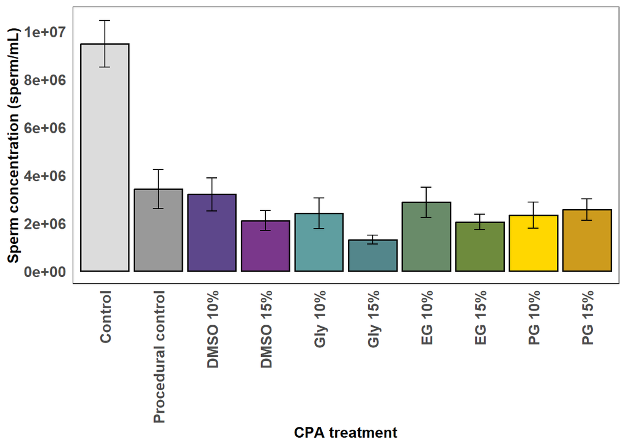

```r
SpermTox_mean$Treatment <- factor(SpermTox_mean$Treatment, levels = c("Control", "Procedural control", "DMSO 10%", "DMSO 15%", "Gly 10%", "Gly 15%", "EG 10%", "EG 15%", "PG 10%", "PG 15%"))

plot <- SpermTox_mean %>%
ggplot(aes(x= Treatment, y= Density_mean, fill = Treatment)) +
  geom_bar(stat="identity", color="black",
           position=position_dodge(), linewidth = 0.6) +
 geom_errorbar(aes(ymin=Density_mean-se_conc, ymax=Density_mean+se_conc), width=.2, position=position_dodge(0.9)) +
Theme1 +
labs( y="Sperm concentration (sperm/mL)", x="CPA treatment") +
theme(axis.text.x = element_text(angle = 90, vjust = 0.5, hjust=1))+
  scale_y_continuous(limits = c(0, 10500000), breaks = seq(0,10000000, by = 2000000)) +
scale_fill_manual(
    values = c("DMSO 10%" = "mediumpurple4", "DMSO 15%" = "mediumorchid4", "PG 10%" = "gold", "PG 15%" = "goldenrod3", "Gly 10%" = "cadetblue", "Gly 15%" = "cadetblue4", "EG 10%" = "darkseagreen4", "EG 15%" = "darkolivegreen4","Control" = "gainsboro", "Procedural control" = "gray60"))+ theme(legend.position="none")



plot
```

```r
ggsave("Density_E1.jpeg", width = 15.3, height = 10, units = "cm")
```

### ii. Sperm motility

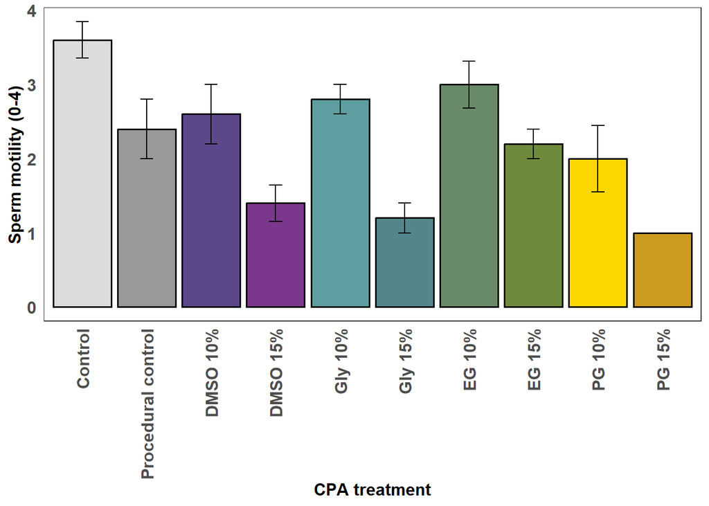

```r
plot <- SpermTox_mean %>%
ggplot(aes(x= Treatment, y= Motility_mean, fill = Treatment)) +
  geom_bar(stat="identity", color="black",
           position=position_dodge(), linewidth = 0.6) +
 geom_errorbar(aes(ymin=Motility_mean-se, ymax=Motility_mean+se), width=.2, position=position_dodge(0.9)) +
Theme1 +
labs( y="Sperm motility (0-4)", x="CPA treatment") +
theme(axis.text.x = element_text(angle = 90, vjust = 0.5, hjust=1)) +
scale_fill_manual(
    values = c("DMSO 10%" = "mediumpurple4", "DMSO 15%" = "mediumorchid4", "PG 10%" = "gold", "PG 15%" = "goldenrod3", "Gly 10%" = "cadetblue", "Gly 15%" = "cadetblue4", "EG 10%" = "darkseagreen4", "EG 15%" = "darkolivegreen4","Control" = "gainsboro", "Procedural control" = "gray60"))+ theme(legend.position="none")

plot
```

```r
ggsave("Mot_E1.jpeg", width = 15, height = 10.3, units = "cm")
```

### iii. Sperm speed

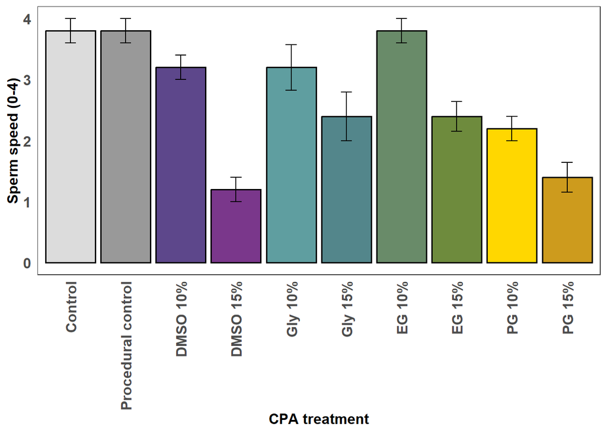

```r
plot <- SpermTox_mean %>%
ggplot(aes(x= Treatment, y= Speed_mean, fill = Treatment)) +
  geom_bar(stat="identity", color="black",
           position=position_dodge(), linewidth = 0.6) +
 geom_errorbar(aes(ymin=Speed_mean-se_speed, ymax=Speed_mean+se_speed), width=.2, position=position_dodge(0.9)) +
Theme1 +
labs( y="Sperm speed (0-4)", x="CPA treatment") +
theme(axis.text.x = element_text(angle = 90, vjust = 0.5, hjust=1)) +
scale_fill_manual(
    values = c("DMSO 10%" = "mediumpurple4", "DMSO 15%" = "mediumorchid4", "PG 10%" = "gold", "PG 15%" = "goldenrod3", "Gly 10%" = "cadetblue", "Gly 15%" = "cadetblue4", "EG 10%" = "darkseagreen4", "EG 15%" = "darkolivegreen4","Control" = "gainsboro", "Procedural control" = "gray60"))+ theme(legend.position="none")

plot
```

```r
ggsave("speed_E1.jpeg", width = 15, height = 10.3, units = "cm")
```

## **2d)** Statistical analyses

### i. Sperm concentration

```r
Sperm_Toxicity$Male <- as.factor(Sperm_Toxicity$Male)

model_tox <- lmer(sqrt(Density) ~ Treatment + (1|Male), data = Sperm_Toxicity)
summary(model_tox)
```

```
## Linear mixed model fit by REML ['lmerMod']
## Formula: sqrt(Density) ~ Treatment + (1 | Male)
##    Data: Sperm_Toxicity
##
## REML criterion at convergence: 583.9
##
## Scaled residuals:
##      Min       1Q   Median       3Q      Max
## -2.78083 -0.64041  0.06894  0.60284  1.76418
##
## Random effects:
##  Groups   Name        Variance Std.Dev.
##  Male     (Intercept) 73435    271.0
##  Residual             66663    258.2
## Number of obs: 50, groups:  Male, 5
##
## Fixed effects:
##                             Estimate Std. Error t value
## (Intercept)                   3059.5      167.4  18.277
## TreatmentDMSO 10%            -1311.5      163.3  -8.031
## TreatmentDMSO 15%            -1631.5      163.3  -9.991
## TreatmentEG 10%              -1410.5      163.3  -8.638
## TreatmentEG 15%              -1645.2      163.3 -10.075
## TreatmentGly 10%             -1564.2      163.3  -9.579
## TreatmentGly 15%             -1925.9      163.3 -11.794
## TreatmentPG 10%              -1571.3      163.3  -9.623
## TreatmentPG 15%              -1479.6      163.3  -9.061
## TreatmentProcedural control  -1260.7      163.3  -7.720
##
## Correlation of Fixed Effects:
##             (Intr) TDMSO10 TDMSO15 TEG10% TEG15% TrG10% TrG15% TPG10% TPG15%
## TrtmDMSO10% -0.488
## TrtmDMSO15% -0.488  0.500
## TrtmntEG10% -0.488  0.500   0.500
## TrtmntEG15% -0.488  0.500   0.500   0.500
## TrtmntGl10% -0.488  0.500   0.500   0.500  0.500
## TrtmntGl15% -0.488  0.500   0.500   0.500  0.500  0.500
## TrtmntPG10% -0.488  0.500   0.500   0.500  0.500  0.500  0.500
## TrtmntPG15% -0.488  0.500   0.500   0.500  0.500  0.500  0.500  0.500
## TrtmntPrcdc -0.488  0.500   0.500   0.500  0.500  0.500  0.500  0.500  0.500
```

```r
car::Anova(model_tox)
```

```
## Analysis of Deviance Table (Type II Wald chisquare tests)
##
## Response: sqrt(Density)
##            Chisq Df Pr(>Chisq)
## Treatment 182.73  9  < 2.2e-16 ***
## ---
## Signif. codes:  0 '***' 0.001 '**' 0.01 '*' 0.05 '.' 0.1 ' ' 1
```

Contrasts:

```r
emmeans(model_tox, specs = pairwise ~ Treatment, type = "response", adjust = "none")
```

```
## $emmeans
##  Treatment          response      SE   df lower.CL upper.CL
##  Control             9360300 1024250 11.5  7252514 11736602
##  DMSO 10%            3055525  585199 11.5  1908803  4470762
##  DMSO 15%            2039210  478070 11.5  1126989  3219946
##  EG 10%              2719192  552053 11.5  1645026  4061873
##  EG 15%              2000206  473476 11.5  1098041  3170885
##  Gly 10%             2235718  500575 11.5  1274235  3465716
##  Gly 15%             1284906  379487 11.5   588481  2249846
##  PG 10%              2214516  498196 11.5  1258241  3439306
##  PG 15%              2496110  528923 11.5  1472574  3788161
##  Procedural control  3235534  602191 11.5  2051619  4687963
##
## Degrees-of-freedom method: kenward-roger
## Confidence level used: 0.95
## Intervals are back-transformed from the sqrt scale
##
## $contrasts
##  contrast                      estimate  SE df t.ratio p.value
##  Control - DMSO 10%             1311.45 163 36   8.031  <.0001
##  Control - DMSO 15%             1631.45 163 36   9.991  <.0001
##  Control - EG 10%               1410.46 163 36   8.638  <.0001
##  Control - EG 15%               1645.17 163 36  10.075  <.0001
##  Control - Gly 10%              1564.23 163 36   9.579  <.0001
##  Control - Gly 15%              1925.92 163 36  11.794  <.0001
##  Control - PG 10%               1571.34 163 36   9.623  <.0001
##  Control - PG 15%               1479.55 163 36   9.061  <.0001
##  Control - Procedural control   1260.70 163 36   7.720  <.0001
##  DMSO 10% - DMSO 15%             320.00 163 36   1.960  0.0578
##  DMSO 10% - EG 10%                99.01 163 36   0.606  0.5481
##  DMSO 10% - EG 15%               333.72 163 36   2.044  0.0484
##  DMSO 10% - Gly 10%              252.77 163 36   1.548  0.1304
##  DMSO 10% - Gly 15%              614.47 163 36   3.763  0.0006
##  DMSO 10% - PG 10%               259.88 163 36   1.591  0.1202
##  DMSO 10% - PG 15%               168.10 163 36   1.029  0.3102
##  DMSO 10% - Procedural control   -50.75 163 36  -0.311  0.7577
##  DMSO 15% - EG 10%              -220.99 163 36  -1.353  0.1844
##  DMSO 15% - EG 15%                13.72 163 36   0.084  0.9335
##  DMSO 15% - Gly 10%              -67.22 163 36  -0.412  0.6830
##  DMSO 15% - Gly 15%              294.47 163 36   1.803  0.0797
```

[output cut: 12 more lines]

```
##  EG 15% - PG 15%                -165.62 163 36  -1.014  0.3172
##  EG 15% - Procedural control    -384.47 163 36  -2.354  0.0241
##  Gly 10% - Gly 15%               361.69 163 36   2.215  0.0332
##  Gly 10% - PG 10%                  7.11 163 36   0.044  0.9655
##  Gly 10% - PG 15%                -84.68 163 36  -0.519  0.6072
##  Gly 10% - Procedural control   -303.53 163 36  -1.859  0.0713
##  Gly 15% - PG 10%               -354.59 163 36  -2.171  0.0366
##  Gly 15% - PG 15%               -446.37 163 36  -2.734  0.0097
##  Gly 15% - Procedural control   -665.22 163 36  -4.074  0.0002
##  PG 10% - PG 15%                 -91.78 163 36  -0.562  0.5776
##  PG 10% - Procedural control    -310.63 163 36  -1.902  0.0652
##  PG 15% - Procedural control    -218.85 163 36  -1.340  0.1886
##
## Note: contrasts are still on the sqrt scale
## Degrees-of-freedom method: kenward-roger
```

Check model assumptions:

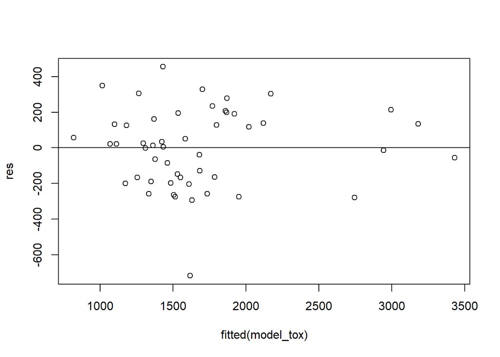

```r
res <- resid(model_tox)

#produce residual vs. fitted plot
plot(fitted(model_tox), res)

#add a horizontal line at 0
abline(0,0)
```

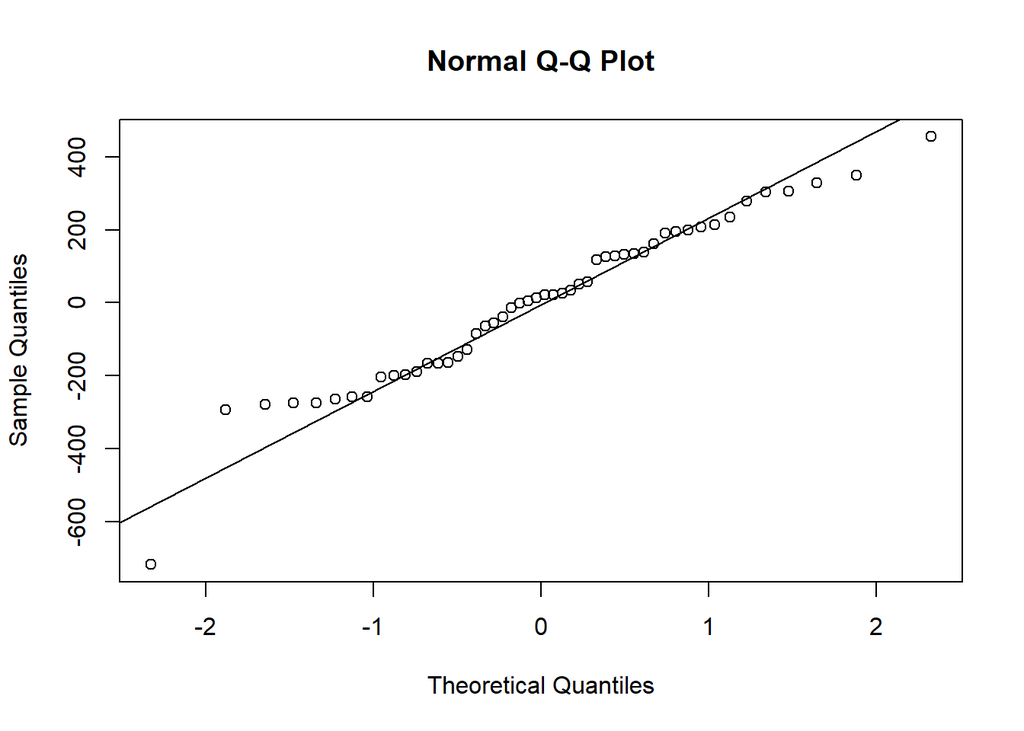

```r
#create Q-Q plot for residuals
qqnorm(res)

#add a straight diagonal line to the plot
qqline(res)
```

### ii. Sperm motility

```r
Sperm_Toxicity$Male <- as.factor(Sperm_Toxicity$Male)

model_tox <- lmer(sqrt(Motility) ~ Treatment + (1|Male), data = Sperm_Toxicity)
summary(model_tox)
```

```
## Linear mixed model fit by REML ['lmerMod']
## Formula: sqrt(Motility) ~ Treatment + (1 | Male)
##    Data: Sperm_Toxicity
##
## REML criterion at convergence: 3.9
##
## Scaled residuals:
##     Min      1Q  Median      3Q     Max
## -1.8694 -0.6259 -0.1781  0.3566  2.0690
##
## Random effects:
##  Groups   Name        Variance Std.Dev.
##  Male     (Intercept) 0.007771 0.08815
##  Residual             0.038639 0.19657
## Number of obs: 50, groups:  Male, 5
##
## Fixed effects:
##                             Estimate Std. Error t value
## (Intercept)                  1.89282    0.09634  19.647
## TreatmentDMSO 10%           -0.29788    0.12432  -2.396
## TreatmentDMSO 15%           -0.72713    0.12432  -5.849
## TreatmentEG 10%             -0.17075    0.12432  -1.373
## TreatmentEG 15%             -0.41504    0.12432  -3.338
## TreatmentGly 10%            -0.22434    0.12432  -1.805
## TreatmentGly 15%            -0.80998    0.12432  -6.515
## TreatmentPG 10%             -0.51716    0.12432  -4.160
## TreatmentPG 15%             -0.89282    0.12432  -7.182
## TreatmentProcedural control -0.36145    0.12432  -2.907
##
## Correlation of Fixed Effects:
##             (Intr) TDMSO10 TDMSO15 TEG10% TEG15% TrG10% TrG15% TPG10% TPG15%
## TrtmDMSO10% -0.645
## TrtmDMSO15% -0.645  0.500
## TrtmntEG10% -0.645  0.500   0.500
## TrtmntEG15% -0.645  0.500   0.500   0.500
## TrtmntGl10% -0.645  0.500   0.500   0.500  0.500
## TrtmntGl15% -0.645  0.500   0.500   0.500  0.500  0.500
## TrtmntPG10% -0.645  0.500   0.500   0.500  0.500  0.500  0.500
## TrtmntPG15% -0.645  0.500   0.500   0.500  0.500  0.500  0.500  0.500
## TrtmntPrcdc -0.645  0.500   0.500   0.500  0.500  0.500  0.500  0.500  0.500
```

```r
car::Anova(model_tox)
```

```
## Analysis of Deviance Table (Type II Wald chisquare tests)
##
## Response: sqrt(Motility)
##            Chisq Df Pr(>Chisq)
## Treatment 99.628  9  < 2.2e-16 ***
## ---
## Signif. codes:  0 '***' 0.001 '**' 0.01 '*' 0.05 '.' 0.1 ' ' 1
```

Contrasts:

```r
emmeans(model_tox, specs = pairwise ~ Treatment, type = "response", adjust = "none")
```

```
## $emmeans
##  Treatment          response    SE   df lower.CL upper.CL
##  Control                3.58 0.365 31.9    2.878     4.36
##  DMSO 10%               2.54 0.307 31.9    1.956     3.21
##  DMSO 15%               1.36 0.225 31.9    0.940     1.85
##  EG 10%                 2.97 0.332 31.9    2.328     3.68
##  EG 15%                 2.18 0.285 31.9    1.642     2.80
##  Gly 10%                2.78 0.321 31.9    2.167     3.48
##  Gly 15%                1.17 0.209 31.9    0.786     1.64
##  PG 10%                 1.89 0.265 31.9    1.391     2.47
##  PG 15%                 1.00 0.193 31.9    0.646     1.43
##  Procedural control     2.35 0.295 31.9    1.783     2.98
##
## Degrees-of-freedom method: kenward-roger
## Confidence level used: 0.95
## Intervals are back-transformed from the sqrt scale
##
## $contrasts
##  contrast                      estimate    SE df t.ratio p.value
##  Control - DMSO 10%              0.2979 0.124 36   2.396  0.0219
##  Control - DMSO 15%              0.7271 0.124 36   5.849  <.0001
##  Control - EG 10%                0.1707 0.124 36   1.373  0.1781
##  Control - EG 15%                0.4150 0.124 36   3.338  0.0020
##  Control - Gly 10%               0.2243 0.124 36   1.805  0.0795
##  Control - Gly 15%               0.8100 0.124 36   6.515  <.0001
##  Control - PG 10%                0.5172 0.124 36   4.160  0.0002
##  Control - PG 15%                0.8928 0.124 36   7.182  <.0001
##  Control - Procedural control    0.3614 0.124 36   2.907  0.0062
##  DMSO 10% - DMSO 15%             0.4293 0.124 36   3.453  0.0014
##  DMSO 10% - EG 10%              -0.1271 0.124 36  -1.023  0.3133
##  DMSO 10% - EG 15%               0.1172 0.124 36   0.942  0.3523
##  DMSO 10% - Gly 10%             -0.0735 0.124 36  -0.592  0.5578
##  DMSO 10% - Gly 15%              0.5121 0.124 36   4.119  0.0002
##  DMSO 10% - PG 10%               0.2193 0.124 36   1.764  0.0863
##  DMSO 10% - PG 15%               0.5949 0.124 36   4.786  <.0001
##  DMSO 10% - Procedural control   0.0636 0.124 36   0.511  0.6122
##  DMSO 15% - EG 10%              -0.5564 0.124 36  -4.475  0.0001
##  DMSO 15% - EG 15%              -0.3121 0.124 36  -2.510  0.0167
##  DMSO 15% - Gly 10%             -0.5028 0.124 36  -4.044  0.0003
##  DMSO 15% - Gly 15%              0.0828 0.124 36   0.666  0.5094
```

[output cut: 12 more lines]

```
##  EG 15% - PG 15%                 0.4778 0.124 36   3.843  0.0005
##  EG 15% - Procedural control    -0.0536 0.124 36  -0.431  0.6690
##  Gly 10% - Gly 15%               0.5856 0.124 36   4.711  <.0001
##  Gly 10% - PG 10%                0.2928 0.124 36   2.355  0.0241
##  Gly 10% - PG 15%                0.6685 0.124 36   5.377  <.0001
##  Gly 10% - Procedural control    0.1371 0.124 36   1.103  0.2774
##  Gly 15% - PG 10%               -0.2928 0.124 36  -2.355  0.0241
##  Gly 15% - PG 15%                0.0828 0.124 36   0.666  0.5094
##  Gly 15% - Procedural control   -0.4485 0.124 36  -3.608  0.0009
##  PG 10% - PG 15%                 0.3757 0.124 36   3.022  0.0046
##  PG 10% - Procedural control    -0.1557 0.124 36  -1.252  0.2185
##  PG 15% - Procedural control    -0.5314 0.124 36  -4.274  0.0001
##
## Note: contrasts are still on the sqrt scale
## Degrees-of-freedom method: kenward-roger
```

Check model assumptions:

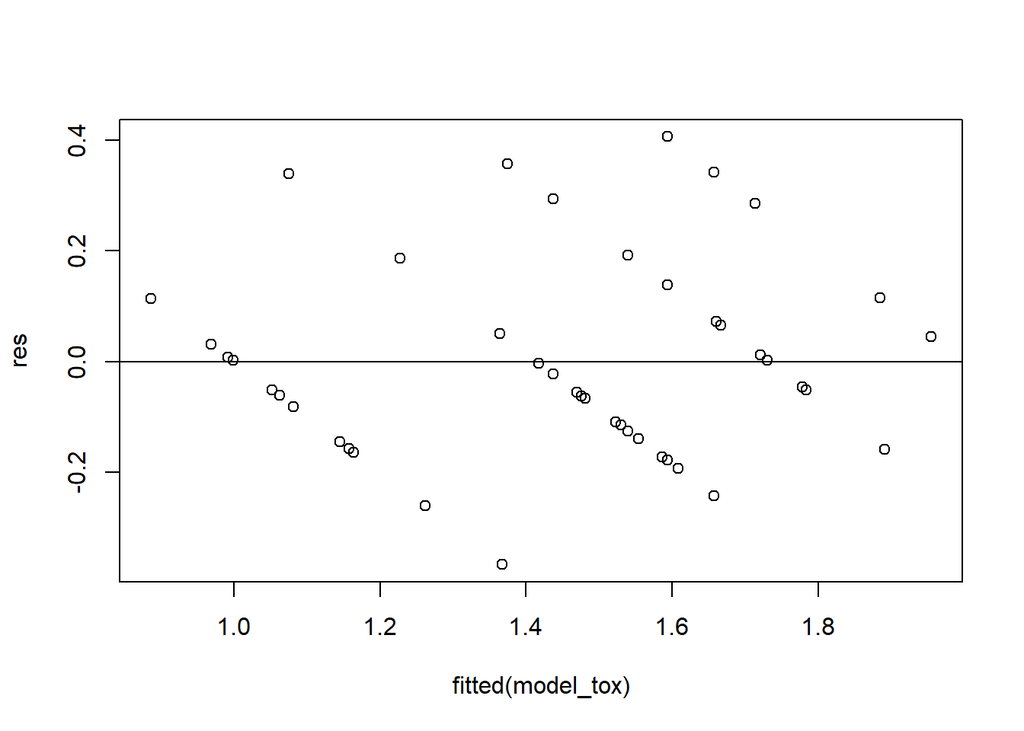

```r
res <- resid(model_tox)

#produce residual vs. fitted plot
plot(fitted(model_tox), res)

#add a horizontal line at 0
abline(0,0)
```

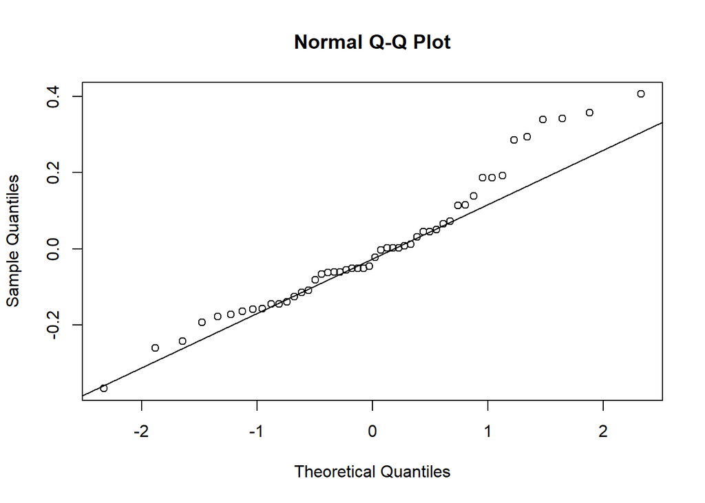

```r
#create Q-Q plot for residuals
qqnorm(res)

#add a straight diagonal line to the plot
qqline(res)
```

### iii. Sperm speed

```r
model_tox <- lmer(sqrt(Speed) ~ Treatment + (1|Male), data = Sperm_Toxicity)
summary(model_tox)
```

```
## Linear mixed model fit by REML ['lmerMod']
## Formula: sqrt(Speed) ~ Treatment + (1 | Male)
##    Data: Sperm_Toxicity
##
## REML criterion at convergence: -6.8
##
## Scaled residuals:
##      Min       1Q   Median       3Q      Max
## -3.08006 -0.56081 -0.01601  0.30806  1.58118
##
## Random effects:
##  Groups   Name        Variance Std.Dev.
##  Male     (Intercept) 0.006166 0.07852
##  Residual             0.029497 0.17175
## Number of obs: 50, groups:  Male, 5
##
## Fixed effects:
##                               Estimate Std. Error t value
## (Intercept)                  1.946e+00  8.445e-02  23.047
## TreatmentDMSO 10%           -1.608e-01  1.086e-01  -1.480
## TreatmentDMSO 15%           -8.636e-01  1.086e-01  -7.950
## TreatmentEG 10%             -7.962e-16  1.086e-01   0.000
## TreatmentEG 15%             -4.051e-01  1.086e-01  -3.729
## TreatmentGly 10%            -1.707e-01  1.086e-01  -1.572
## TreatmentGly 15%            -4.243e-01  1.086e-01  -3.907
## TreatmentPG 10%             -4.686e-01  1.086e-01  -4.314
## TreatmentPG 15%             -7.807e-01  1.086e-01  -7.188
## TreatmentProcedural control -1.066e-15  1.086e-01   0.000
##
## Correlation of Fixed Effects:
##             (Intr) TDMSO10 TDMSO15 TEG10% TEG15% TrG10% TrG15% TPG10% TPG15%
## TrtmDMSO10% -0.643
## TrtmDMSO15% -0.643  0.500
## TrtmntEG10% -0.643  0.500   0.500
## TrtmntEG15% -0.643  0.500   0.500   0.500
## TrtmntGl10% -0.643  0.500   0.500   0.500  0.500
## TrtmntGl15% -0.643  0.500   0.500   0.500  0.500  0.500
## TrtmntPG10% -0.643  0.500   0.500   0.500  0.500  0.500  0.500
## TrtmntPG15% -0.643  0.500   0.500   0.500  0.500  0.500  0.500  0.500
## TrtmntPrcdc -0.643  0.500   0.500   0.500  0.500  0.500  0.500  0.500  0.500
```

```r
car::Anova(model_tox)
```

```
## Analysis of Deviance Table (Type II Wald chisquare tests)
##
## Response: sqrt(Speed)
##            Chisq Df Pr(>Chisq)
## Treatment 152.94  9  < 2.2e-16 ***
## ---
## Signif. codes:  0 '***' 0.001 '**' 0.01 '*' 0.05 '.' 0.1 ' ' 1
```

Contrasts:

```r
emmeans(model_tox, specs = pairwise ~ Treatment, type = "response", adjust = "none")
```

```
## $emmeans
##  Treatment          response    SE   df lower.CL upper.CL
##  Control                3.79 0.329 31.5    3.148     4.49
##  DMSO 10%               3.19 0.302 31.5    2.603     3.83
##  DMSO 15%               1.17 0.183 31.5    0.829     1.57
##  EG 10%                 3.79 0.329 31.5    3.148     4.49
##  EG 15%                 2.38 0.260 31.5    1.875     2.94
##  Gly 10%                3.15 0.300 31.5    2.571     3.79
##  Gly 15%                2.32 0.257 31.5    1.822     2.87
##  PG 10%                 2.18 0.250 31.5    1.705     2.72
##  PG 15%                 1.36 0.197 31.5    0.987     1.79
##  Procedural control     3.79 0.329 31.5    3.148     4.49
##
## Degrees-of-freedom method: kenward-roger
## Confidence level used: 0.95
## Intervals are back-transformed from the sqrt scale
##
## $contrasts
##  contrast                      estimate    SE df t.ratio p.value
##  Control - DMSO 10%             0.16077 0.109 36   1.480  0.1476
##  Control - DMSO 15%             0.86357 0.109 36   7.950  <.0001
##  Control - EG 10%               0.00000 0.109 36   0.000  1.0000
##  Control - EG 15%               0.40506 0.109 36   3.729  0.0007
##  Control - Gly 10%              0.17075 0.109 36   1.572  0.1247
##  Control - Gly 15%              0.42434 0.109 36   3.907  0.0004
##  Control - PG 10%               0.46863 0.109 36   4.314  0.0001
##  Control - PG 15%               0.78072 0.109 36   7.188  <.0001
##  Control - Procedural control   0.00000 0.109 36   0.000  1.0000
##  DMSO 10% - DMSO 15%            0.70280 0.109 36   6.470  <.0001
##  DMSO 10% - EG 10%             -0.16077 0.109 36  -1.480  0.1476
##  DMSO 10% - EG 15%              0.24429 0.109 36   2.249  0.0307
##  DMSO 10% - Gly 10%             0.00998 0.109 36   0.092  0.9273
##  DMSO 10% - Gly 15%             0.26357 0.109 36   2.426  0.0204
##  DMSO 10% - PG 10%              0.30786 0.109 36   2.834  0.0075
##  DMSO 10% - PG 15%              0.61996 0.109 36   5.707  <.0001
##  DMSO 10% - Procedural control -0.16077 0.109 36  -1.480  0.1476
##  DMSO 15% - EG 10%             -0.86357 0.109 36  -7.950  <.0001
##  DMSO 15% - EG 15%             -0.45851 0.109 36  -4.221  0.0002
##  DMSO 15% - Gly 10%            -0.69282 0.109 36  -6.378  <.0001
##  DMSO 15% - Gly 15%            -0.43923 0.109 36  -4.044  0.0003
```

[output cut: 12 more lines]

```
##  EG 15% - PG 15%                0.37566 0.109 36   3.458  0.0014
##  EG 15% - Procedural control   -0.40506 0.109 36  -3.729  0.0007
##  Gly 10% - Gly 15%              0.25359 0.109 36   2.335  0.0253
##  Gly 10% - PG 10%               0.29788 0.109 36   2.742  0.0094
##  Gly 10% - PG 15%               0.60998 0.109 36   5.616  <.0001
##  Gly 10% - Procedural control  -0.17075 0.109 36  -1.572  0.1247
##  Gly 15% - PG 10%               0.04429 0.109 36   0.408  0.6859
##  Gly 15% - PG 15%               0.35639 0.109 36   3.281  0.0023
##  Gly 15% - Procedural control  -0.42434 0.109 36  -3.907  0.0004
##  PG 10% - PG 15%                0.31210 0.109 36   2.873  0.0068
##  PG 10% - Procedural control   -0.46863 0.109 36  -4.314  0.0001
##  PG 15% - Procedural control   -0.78072 0.109 36  -7.188  <.0001
##
## Note: contrasts are still on the sqrt scale
## Degrees-of-freedom method: kenward-roger
```

Check model assumptions:

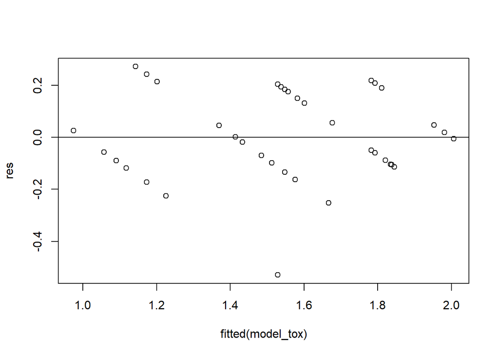

```r
res <- resid(model_tox)

#produce residual vs. fitted plot
plot(fitted(model_tox), res)

#add a horizontal line at 0
abline(0,0)
```

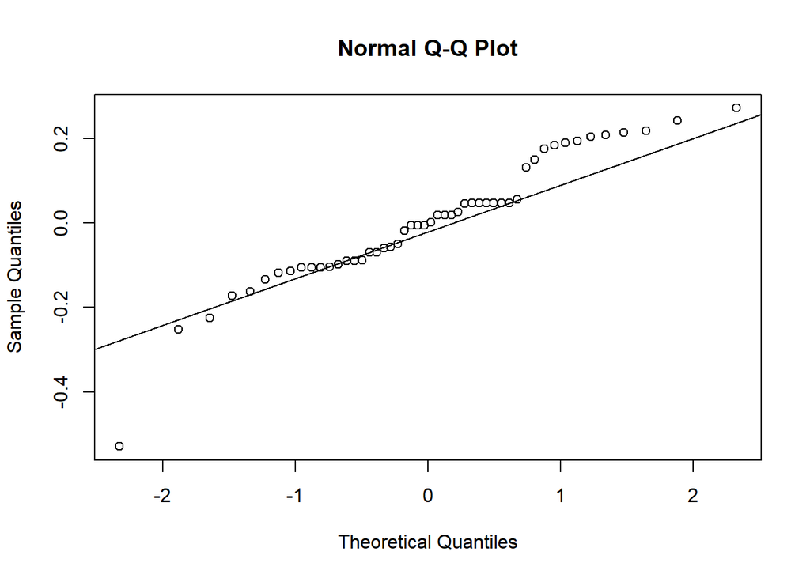

```r
#create Q-Q plot for residuals
qqnorm(res)

#add a straight diagonal line to the plot
qqline(res)
```

# **3.** Experiment 2: Sperm viability after thawing

# **3a)** Import data

```r
Sperm_2025 <- read.csv("Data_cryo/Sperm_freezing_2025.csv")
```

## **3b)** Data structure and summary

1. Check structure

```r
str(Sperm_2025)
```

```
## 'data.frame':    83 obs. of  19 variables:
##  $ Male          : int  9 8 13 14 4 9 9 9 9 9 ...
##  $ Repeat        : int  1 1 1 1 1 1 1 1 2 2 ...
##  $ CPA           : chr  "Control" "Control" "Control" "Control" ...
##  $ Concentration : int  NA NA NA NA NA 15 15 10 10 15 ...
##  $ Treatment     : chr  "Control" "Control" "Control" "Control" ...
##  $ Rate          : chr  "" "" "" "" ...
##  $ Freezing_rate : num  NA NA NA NA NA -34.4 -34.4 -34.4 -34.4 -34.4 ...
##  $ Straw         : int  0 0 0 0 0 1 2 3 4 5 ...
##  $ Mean_rate     : num  NA NA NA NA NA ...
##  $ SE_rate       : num  NA NA NA NA NA ...
##  $ Heamocytometer: int  4200000 4450000 2500000 2500000 3150000 NA NA NA NA NA ...
##  $ M_ml          : num  8.24 9.21 3.03 5.47 5.97 1.25 1.49 0.86 1.42 1.05 ...
##  $ Density_CASA  : int  8240000 9210000 3030000 5470000 5970000 1250000 1490000 860000 1420000 1050000 ...
##  $ Motility      : int  3 2 2 2 3 1 1 1 1 0 ...
##  $ Speed         : int  3 3 2 3 4 1 1 0 2 0 ...
##  $ Motility_CASA : num  50.9 35.4 40.2 33.6 63.9 23.5 48 16 43.6 26 ...
##  $ number_motile : int  108 84 47 71 131 3 17 1 25 0 ...
##  $ Total_count   : int  212 237 117 211 205 102 102 100 110 104 ...
##  $ Percent_motile: num  50.9 35.4 40.2 33.6 63.9 ...
```

2. Average duplicates

```r
Sperm_2025_1 <- Sperm_2025 %>%
  group_by(Male, Treatment)%>%
  summarise(Density = mean(Density_CASA), Motility = mean(Motility), Speed = mean(Speed), Percent_motile = mean(Percent_motile))
```

```r
Sperm_mean2025 <- Sperm_2025_1 %>%
  group_by (Treatment)  %>%
  summarise(Density_mean = mean(Density), n = n(), sd_conc = sd(Density), se_conc = sd_conc/sqrt(n), Motility_mean = mean(Motility), sd_motility = sd(Motility), se_motility = sd_motility/sqrt(n), Speed_mean = mean(Speed), sd_speed = sd(Speed), se_speed = sd_speed/sqrt(n), Motile_mean = mean(Percent_motile), sd_mot = sd(Percent_motile), se_mot = sd_mot/sqrt(n))
```

## **3c)** Visualise patterns

### i. Sperm concentration

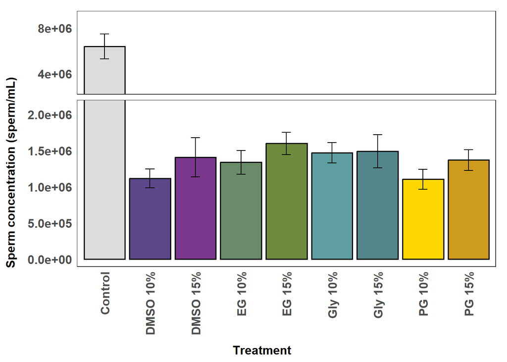

```r
Sperm_mean$Treatment <- factor(Sperm_mean$Treatment, levels = c("Control", "DMSO 10%", "DMSO 15%", "Gly 10%", "Gly 15%", "EG 10%", "EG 15%", "PG 10%", "PG 15%"))

plot <- Sperm_mean2025 %>%
ggplot(aes(x= Treatment, y= Density_mean, fill = Treatment)) +
  geom_bar(stat="identity", color="black",
           position=position_dodge(), linewidth = 0.6) +
 geom_errorbar(aes(ymin=Density_mean-se_conc, ymax=Density_mean+se_conc), width=.2, position=position_dodge(0.9)) +
Theme1 +
labs( y="Sperm concentration (sperm/mL)", x="Treatment")   +
  scale_fill_viridis(discrete = TRUE) +
  theme(legend.key.size = unit(0.6, 'cm'), #change legend key size
        legend.key.height = unit(0.6, 'cm'), #change legend key height
        legend.key.width = unit(0.6, 'cm'), #change legend key width
        legend.title = element_text(size=12), #change legend title font size
        legend.text = element_text(size=10)) #change legend text font size


p1 <- plot +scale_y_cut(breaks=c(2200000), which=c(2, 1), scales=c(4, 2)) +
  scale_y_continuous(
    breaks = c(seq(0, 2000000, by = 500000), seq(4000000, 8000000, by = 4000000)), limits = c(-100000, 9500000),  # Adjust tick marks
    labels = label_scientific())             # Customize labels
p1 +
theme(axis.text.x = element_text(angle = 90, vjust = 0.5, hjust=1)) +
scale_fill_manual(
    values = c("DMSO 10%" = "mediumpurple4", "DMSO 15%" = "mediumorchid4", "PG 10%" = "gold", "PG 15%" = "goldenrod3", "Gly 10%" = "cadetblue", "Gly 15%" = "cadetblue4", "EG 10%" = "darkseagreen4", "EG 15%" = "darkolivegreen4","Control" = "gainsboro"))+ theme(legend.position="none")
```

```r
ggsave("Density_EXP2_SPERM.jpeg", width = 15.5, height = 8.7, units = "cm")
```

### ii. Sperm motility

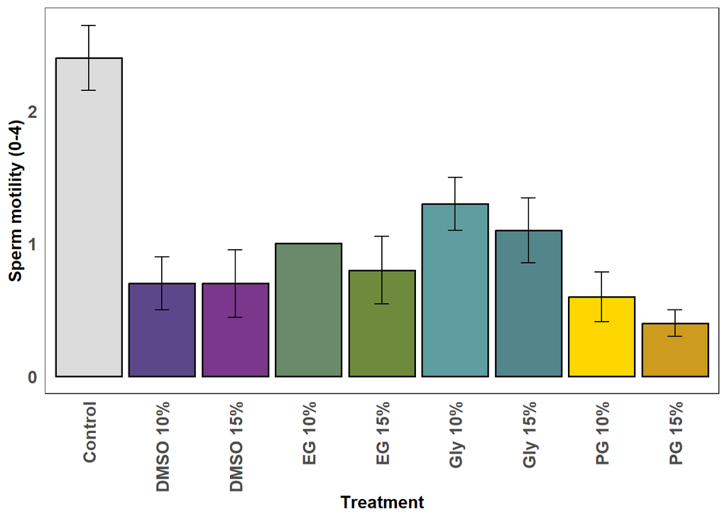

```r
plot <- Sperm_mean2025 %>%
ggplot(aes(x= Treatment, y= Motility_mean, fill = Treatment)) +
  geom_bar(stat="identity", color="black",
           position=position_dodge(), linewidth = 0.6) +
 geom_errorbar(aes(ymin=Motility_mean-se_motility, ymax=Motility_mean+se_motility), width=.2, position=position_dodge(0.9)) +
Theme1 +
labs( y="Sperm motility (0-4)", x="Treatment")   +
  scale_fill_viridis(discrete = TRUE) +
  theme(legend.key.size = unit(0.6, 'cm'), #change legend key size
        legend.key.height = unit(0.6, 'cm'), #change legend key height
        legend.key.width = unit(0.6, 'cm'), #change legend key width
        legend.title = element_text(size=12), #change legend title font size
        legend.text = element_text(size=10)) +
theme(axis.text.x = element_text(angle = 90, vjust = 0.5, hjust=1)) +
scale_fill_manual(
    values = c("DMSO 10%" = "mediumpurple4", "DMSO 15%" = "mediumorchid4", "PG 10%" = "gold", "PG 15%" = "goldenrod3", "Gly 10%" = "cadetblue", "Gly 15%" = "cadetblue4", "EG 10%" = "darkseagreen4", "EG 15%" = "darkolivegreen4","Control" = "gainsboro"))+ theme(legend.position="none")
plot
```

```r
ggsave("Motility_EXP2_SPERM.jpeg", width = 15.5, height = 8.7, units = "cm")
```

### iii. Sperm speed

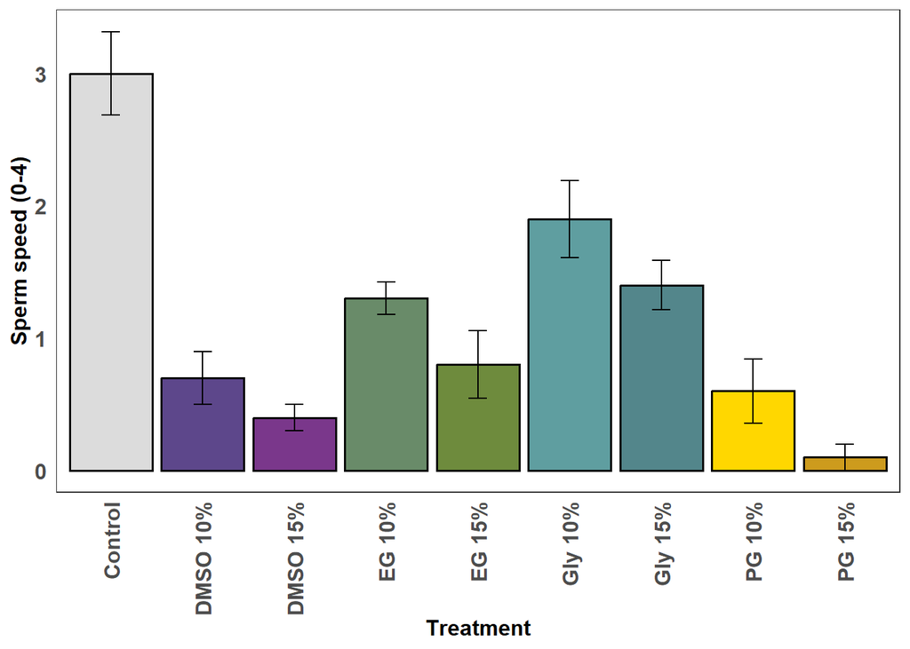

```r
plot <- Sperm_mean2025 %>%
ggplot(aes(x= Treatment, y= Speed_mean, fill = Treatment)) +
  geom_bar(stat="identity", color="black",
           position=position_dodge(), linewidth = 0.6) +
 geom_errorbar(aes(ymin=Speed_mean-se_speed, ymax=Speed_mean+se_speed), width=.2, position=position_dodge(0.9)) +
Theme1 +
labs( y="Sperm speed (0-4)", x="Treatment")   +
  scale_fill_viridis(discrete = TRUE) +
  theme(legend.key.size = unit(0.6, 'cm'), #change legend key size
        legend.key.height = unit(0.6, 'cm'), #change legend key height
        legend.key.width = unit(0.6, 'cm'), #change legend key width
        legend.title = element_text(size=12), #change legend title font size
        legend.text = element_text(size=10)) +
theme(axis.text.x = element_text(angle = 90, vjust = 0.5, hjust=1)) +
scale_fill_manual(
    values = c("DMSO 10%" = "mediumpurple4", "DMSO 15%" = "mediumorchid4", "PG 10%" = "gold", "PG 15%" = "goldenrod3", "Gly 10%" = "cadetblue", "Gly 15%" = "cadetblue4", "EG 10%" = "darkseagreen4", "EG 15%" = "darkolivegreen4","Control" = "gainsboro"))+ theme(legend.position="none")
plot
```

```r
ggsave("Speed_EXP2_SPERM.jpeg", width = 15.5, height = 8.7, units = "cm")
```

### iv. Sperm motility CASA %

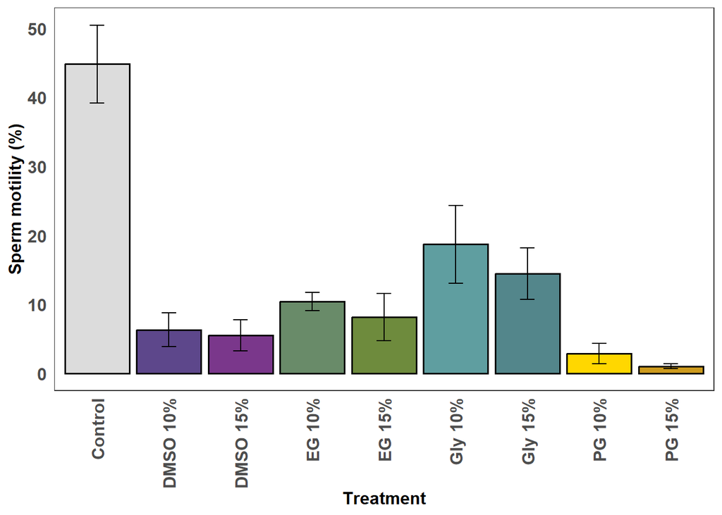

```r
plot <- Sperm_mean2025 %>%
ggplot(aes(x= Treatment, y= Motile_mean, fill = Treatment)) +
  geom_bar(stat="identity", color="black",
           position=position_dodge(), linewidth = 0.6) +
 geom_errorbar(aes(ymin=Motile_mean-se_mot, ymax=Motile_mean+se_mot), width=.2, position=position_dodge(0.9)) +
Theme1 +
labs( y="Sperm motility (%)", x="Treatment")   +
  scale_fill_viridis(discrete = TRUE) +
  theme(legend.key.size = unit(0.6, 'cm'), #change legend key size
        legend.key.height = unit(0.6, 'cm'), #change legend key height
        legend.key.width = unit(0.6, 'cm'), #change legend key width
        legend.title = element_text(size=12), #change legend title font size
        legend.text = element_text(size=10)) +
theme(axis.text.x = element_text(angle = 90, vjust = 0.5, hjust=1)) +
scale_fill_manual(
    values = c("DMSO 10%" = "mediumpurple4", "DMSO 15%" = "mediumorchid4", "PG 10%" = "gold", "PG 15%" = "goldenrod3", "Gly 10%" = "cadetblue", "Gly 15%" = "cadetblue4", "EG 10%" = "darkseagreen4", "EG 15%" = "darkolivegreen4","Control" = "gainsboro"))+ theme(legend.position="none")
plot
```

```r
ggsave("MotilityPERCENT_EXP2_SPERM.jpeg", width = 15.5, height = 8.7, units = "cm")
```

## **3d)** Statistical analyses

### i. Sperm concentration

```r
Sperm_2025_1$Male <- as.factor(Sperm_2025_1$Male)

model <- lmer(sqrt(Density) ~ Treatment + (1|Male), data = Sperm_2025_1)
summary(model)
```

```
## Linear mixed model fit by REML ['lmerMod']
## Formula: sqrt(Density) ~ Treatment + (1 | Male)
##    Data: Sperm_2025_1
##
## REML criterion at convergence: 493.3
##
## Scaled residuals:
##     Min      1Q  Median      3Q     Max
## -3.6883 -0.3028 -0.0668  0.3046  2.1448
##
## Random effects:
##  Groups   Name        Variance Std.Dev.
##  Male     (Intercept) 24401    156.2
##  Residual             27402    165.5
## Number of obs: 45, groups:  Male, 5
##
## Fixed effects:
##                   Estimate Std. Error t value
## (Intercept)         2485.6      101.8   24.42
## TreatmentDMSO 10%  -1436.9      104.7  -13.72
## TreatmentDMSO 15%  -1316.7      104.7  -12.58
## TreatmentEG 10%    -1337.9      104.7  -12.78
## TreatmentEG 15%    -1227.6      104.7  -11.73
## TreatmentGly 10%   -1280.0      104.7  -12.23
## TreatmentGly 15%   -1278.3      104.7  -12.21
## TreatmentPG 10%    -1442.5      104.7  -13.78
## TreatmentPG 15%    -1322.0      104.7  -12.63
##
## Correlation of Fixed Effects:
##             (Intr) TDMSO10 TDMSO15 TEG10% TEG15% TrG10% TrG15% TPG10%
## TrtmDMSO10% -0.514
## TrtmDMSO15% -0.514  0.500
## TrtmntEG10% -0.514  0.500   0.500
## TrtmntEG15% -0.514  0.500   0.500   0.500
## TrtmntGl10% -0.514  0.500   0.500   0.500  0.500
## TrtmntGl15% -0.514  0.500   0.500   0.500  0.500  0.500
## TrtmntPG10% -0.514  0.500   0.500   0.500  0.500  0.500  0.500
## TrtmntPG15% -0.514  0.500   0.500   0.500  0.500  0.500  0.500  0.500
```

```r
car::Anova(model)
```

```
## Analysis of Deviance Table (Type II Wald chisquare tests)
##
## Response: sqrt(Density)
##            Chisq Df Pr(>Chisq)
## Treatment 294.31  8  < 2.2e-16 ***
## ---
## Signif. codes:  0 '***' 0.001 '**' 0.01 '*' 0.05 '.' 0.1 ' ' 1
```

Contrasts:

```r
emmeans(model, specs = pairwise ~ Treatment, type = "response", adjust = "none")
```

```
## $emmeans
##  Treatment response     SE df lower.CL upper.CL
##  Control    6178395 506012 13  5133368  7320173
##  DMSO 10%   1099911 213502 13   686947  1609626
##  DMSO 15%   1366368 237961 13   900550  1928936
##  EG 10%     1317335 233653 13   860828  1870593
##  EG 15%     1582679 256106 13  1077655  2184453
##  Gly 10%    1453568 245437 13   971597  2032290
##  Gly 15%    1457619 245779 13   974909  2037079
##  PG 10%     1088160 212358 13   677667  1595405
##  PG 15%     1353984 236881 13   890502  1914216
##
## Degrees-of-freedom method: kenward-roger
## Confidence level used: 0.95
## Intervals are back-transformed from the sqrt scale
##
## $contrasts
##  contrast            estimate  SE df t.ratio p.value
##  Control - DMSO 10%   1436.87 105 32  13.724  <.0001
##  Control - DMSO 15%   1316.72 105 32  12.577  <.0001
##  Control - EG 10%     1337.89 105 32  12.779  <.0001
##  Control - EG 15%     1227.59 105 32  11.726  <.0001
##  Control - Gly 10%    1280.00 105 32  12.226  <.0001
##  Control - Gly 15%    1278.32 105 32  12.210  <.0001
##  Control - PG 10%     1442.49 105 32  13.778  <.0001
##  Control - PG 15%     1322.03 105 32  12.628  <.0001
##  DMSO 10% - DMSO 15%  -120.15 105 32  -1.148  0.2596
##  DMSO 10% - EG 10%     -98.99 105 32  -0.945  0.3515
##  DMSO 10% - EG 15%    -209.28 105 32  -1.999  0.0542
##  DMSO 10% - Gly 10%   -156.87 105 32  -1.498  0.1438
##  DMSO 10% - Gly 15%   -158.55 105 32  -1.514  0.1397
##  DMSO 10% - PG 10%       5.62 105 32   0.054  0.9575
##  DMSO 10% - PG 15%    -114.84 105 32  -1.097  0.2809
##  DMSO 15% - EG 10%      21.17 105 32   0.202  0.8411
##  DMSO 15% - EG 15%     -89.13 105 32  -0.851  0.4009
##  DMSO 15% - Gly 10%    -36.72 105 32  -0.351  0.7281
##  DMSO 15% - Gly 15%    -38.40 105 32  -0.367  0.7162
##  DMSO 15% - PG 10%     125.77 105 32   1.201  0.2385
##  DMSO 15% - PG 15%       5.31 105 32   0.051  0.9599
##  EG 10% - EG 15%      -110.29 105 32  -1.053  0.3000
##  EG 10% - Gly 10%      -57.89 105 32  -0.553  0.5842
##  EG 10% - Gly 15%      -59.57 105 32  -0.569  0.5734
##  EG 10% - PG 10%       104.60 105 32   0.999  0.3252
##  EG 10% - PG 15%       -15.86 105 32  -0.151  0.8806
##  EG 15% - Gly 10%       52.41 105 32   0.501  0.6201
##  EG 15% - Gly 15%       50.73 105 32   0.485  0.6313
##  EG 15% - PG 10%       214.90 105 32   2.053  0.0484
##  EG 15% - PG 15%        94.44 105 32   0.902  0.3738
##  Gly 10% - Gly 15%      -1.68 105 32  -0.016  0.9873
##  Gly 10% - PG 10%      162.49 105 32   1.552  0.1305
##  Gly 10% - PG 15%       42.03 105 32   0.401  0.6907
##  Gly 15% - PG 10%      164.17 105 32   1.568  0.1267
##  Gly 15% - PG 15%       43.71 105 32   0.418  0.6791
##  PG 10% - PG 15%      -120.46 105 32  -1.151  0.2584
##
## Note: contrasts are still on the sqrt scale
## Degrees-of-freedom method: kenward-roger
```

Check model assumptions:

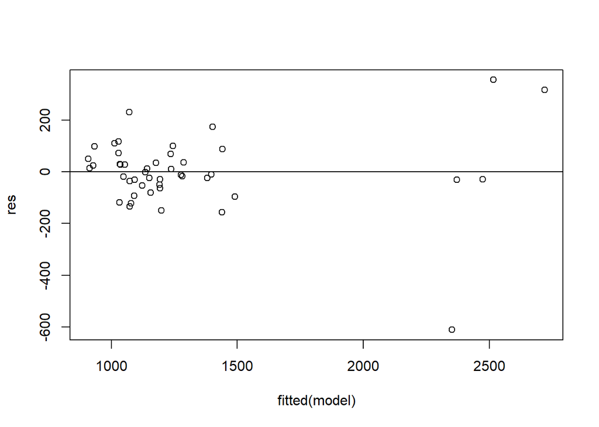

```r
res <- resid(model)

#produce residual vs. fitted plot
plot(fitted(model), res)

#add a horizontal line at 0
abline(0,0)
```

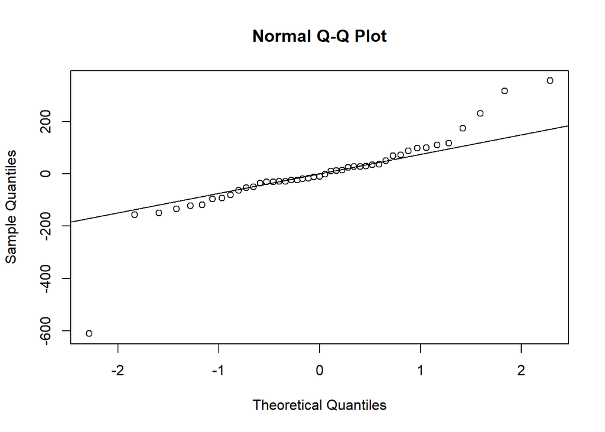

```r
#create Q-Q plot for residuals
qqnorm(res)

#add a straight diagonal line to the plot
qqline(res)
```

### ii. Sperm motility

```r
model <- lmer(Motility ~ Treatment + (1|Male), data = Sperm_2025_1)
summary(model)
```

```
## Linear mixed model fit by REML ['lmerMod']
## Formula: Motility ~ Treatment + (1 | Male)
##    Data: Sperm_2025_1
##
## REML criterion at convergence: 58.8
##
## Scaled residuals:
##      Min       1Q   Median       3Q      Max
## -1.72420 -0.42201 -0.09244  0.51043  1.70209
##
## Random effects:
##  Groups   Name        Variance Std.Dev.
##  Male     (Intercept) 0.02431  0.1559
##  Residual             0.18403  0.4290
## Number of obs: 45, groups:  Male, 5
##
## Fixed effects:
##                   Estimate Std. Error t value
## (Intercept)         2.4000     0.2041  11.758
## TreatmentDMSO 10%  -1.7000     0.2713  -6.266
## TreatmentDMSO 15%  -1.7000     0.2713  -6.266
## TreatmentEG 10%    -1.4000     0.2713  -5.160
## TreatmentEG 15%    -1.6000     0.2713  -5.897
## TreatmentGly 10%   -1.1000     0.2713  -4.054
## TreatmentGly 15%   -1.3000     0.2713  -4.792
## TreatmentPG 10%    -1.8000     0.2713  -6.634
## TreatmentPG 15%    -2.0000     0.2713  -7.372
##
## Correlation of Fixed Effects:
##             (Intr) TDMSO10 TDMSO15 TEG10% TEG15% TrG10% TrG15% TPG10%
## TrtmDMSO10% -0.665
## TrtmDMSO15% -0.665  0.500
## TrtmntEG10% -0.665  0.500   0.500
## TrtmntEG15% -0.665  0.500   0.500   0.500
## TrtmntGl10% -0.665  0.500   0.500   0.500  0.500
## TrtmntGl15% -0.665  0.500   0.500   0.500  0.500  0.500
## TrtmntPG10% -0.665  0.500   0.500   0.500  0.500  0.500  0.500
## TrtmntPG15% -0.665  0.500   0.500   0.500  0.500  0.500  0.500  0.500
```

```r
car::Anova(model)
```

```
## Analysis of Deviance Table (Type II Wald chisquare tests)
##
## Response: Motility
##            Chisq Df Pr(>Chisq)
## Treatment 76.076  8  3.003e-13 ***
## ---
## Signif. codes:  0 '***' 0.001 '**' 0.01 '*' 0.05 '.' 0.1 ' ' 1
```

Contrasts:

```r
emmeans(model, specs = pairwise ~ Treatment, type = "response", adjust = "none")
```

```
## $emmeans
##  Treatment emmean    SE   df lower.CL upper.CL
##  Control      2.4 0.204 32.5   1.9844    2.816
##  DMSO 10%     0.7 0.204 32.5   0.2844    1.116
##  DMSO 15%     0.7 0.204 32.5   0.2844    1.116
##  EG 10%       1.0 0.204 32.5   0.5844    1.416
##  EG 15%       0.8 0.204 32.5   0.3844    1.216
##  Gly 10%      1.3 0.204 32.5   0.8844    1.716
##  Gly 15%      1.1 0.204 32.5   0.6844    1.516
##  PG 10%       0.6 0.204 32.5   0.1844    1.016
##  PG 15%       0.4 0.204 32.5  -0.0156    0.816
##
## Degrees-of-freedom method: kenward-roger
## Confidence level used: 0.95
##
## $contrasts
##  contrast            estimate    SE df t.ratio p.value
##  Control - DMSO 10%       1.7 0.271 32   6.266  <.0001
##  Control - DMSO 15%       1.7 0.271 32   6.266  <.0001
##  Control - EG 10%         1.4 0.271 32   5.160  <.0001
##  Control - EG 15%         1.6 0.271 32   5.897  <.0001
##  Control - Gly 10%        1.1 0.271 32   4.054  0.0003
##  Control - Gly 15%        1.3 0.271 32   4.792  <.0001
##  Control - PG 10%         1.8 0.271 32   6.634  <.0001
##  Control - PG 15%         2.0 0.271 32   7.372  <.0001
##  DMSO 10% - DMSO 15%      0.0 0.271 32   0.000  1.0000
##  DMSO 10% - EG 10%       -0.3 0.271 32  -1.106  0.2771
##  DMSO 10% - EG 15%       -0.1 0.271 32  -0.369  0.7149
##  DMSO 10% - Gly 10%      -0.6 0.271 32  -2.211  0.0343
##  DMSO 10% - Gly 15%      -0.4 0.271 32  -1.474  0.1502
##  DMSO 10% - PG 10%        0.1 0.271 32   0.369  0.7149
##  DMSO 10% - PG 15%        0.3 0.271 32   1.106  0.2771
##  DMSO 15% - EG 10%       -0.3 0.271 32  -1.106  0.2771
##  DMSO 15% - EG 15%       -0.1 0.271 32  -0.369  0.7149
##  DMSO 15% - Gly 10%      -0.6 0.271 32  -2.211  0.0343
##  DMSO 15% - Gly 15%      -0.4 0.271 32  -1.474  0.1502
##  DMSO 15% - PG 10%        0.1 0.271 32   0.369  0.7149
##  DMSO 15% - PG 15%        0.3 0.271 32   1.106  0.2771
##  EG 10% - EG 15%          0.2 0.271 32   0.737  0.4664
##  EG 10% - Gly 10%        -0.3 0.271 32  -1.106  0.2771
##  EG 10% - Gly 15%        -0.1 0.271 32  -0.369  0.7149
##  EG 10% - PG 10%          0.4 0.271 32   1.474  0.1502
##  EG 10% - PG 15%          0.6 0.271 32   2.211  0.0343
##  EG 15% - Gly 10%        -0.5 0.271 32  -1.843  0.0746
##  EG 15% - Gly 15%        -0.3 0.271 32  -1.106  0.2771
##  EG 15% - PG 10%          0.2 0.271 32   0.737  0.4664
##  EG 15% - PG 15%          0.4 0.271 32   1.474  0.1502
##  Gly 10% - Gly 15%        0.2 0.271 32   0.737  0.4664
##  Gly 10% - PG 10%         0.7 0.271 32   2.580  0.0147
##  Gly 10% - PG 15%         0.9 0.271 32   3.317  0.0023
##  Gly 15% - PG 10%         0.5 0.271 32   1.843  0.0746
##  Gly 15% - PG 15%         0.7 0.271 32   2.580  0.0147
##  PG 10% - PG 15%          0.2 0.271 32   0.737  0.4664
##
## Degrees-of-freedom method: kenward-roger
```

Check model assumptions:

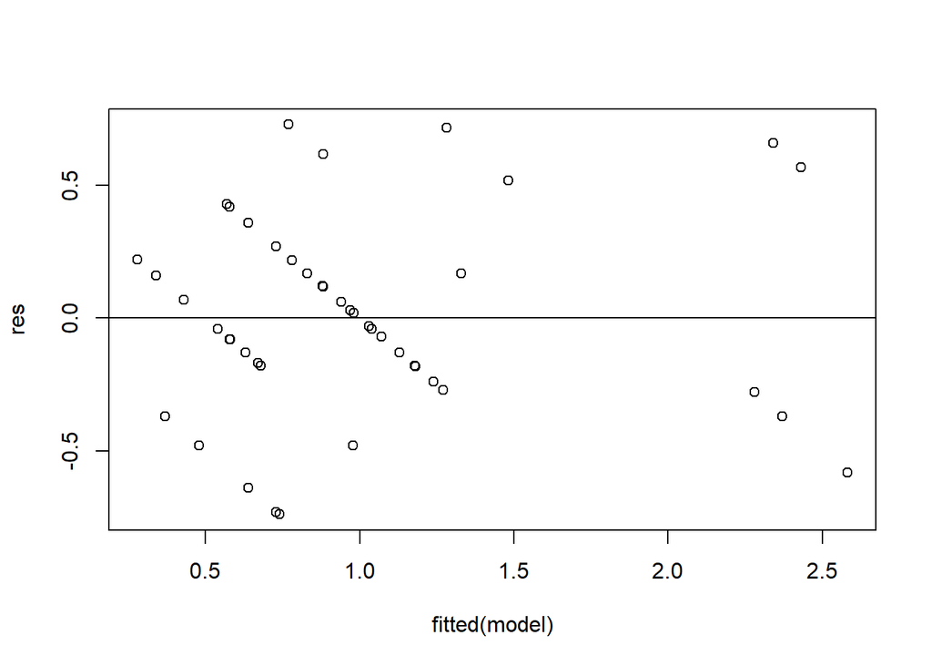

```r
res <- resid(model)

#produce residual vs. fitted plot
plot(fitted(model), res)

#add a horizontal line at 0
abline(0,0)
```

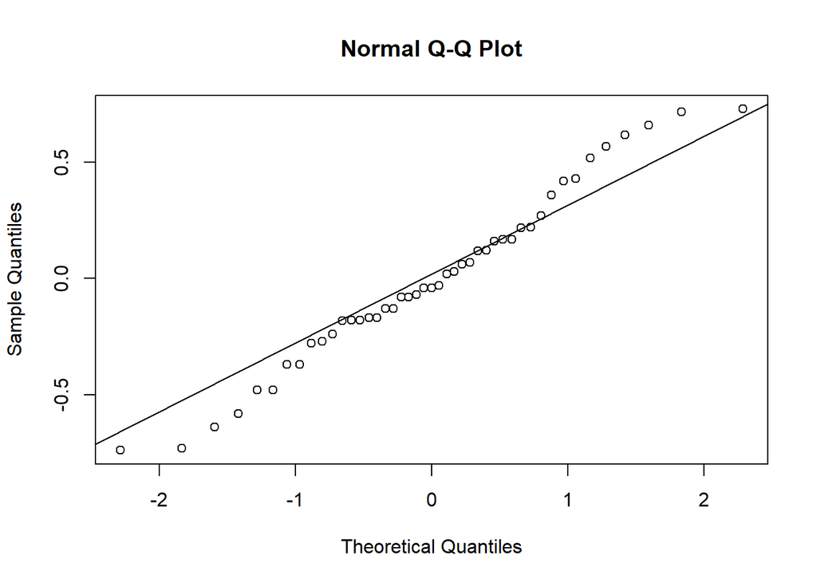

```r
#create Q-Q plot for residuals
qqnorm(res)

#add a straight diagonal line to the plot
qqline(res)
```

### iii. Sperm speed

```r
model <- lmer(Speed ~ Treatment + (1|Male), data = Sperm_2025_1)
summary(model)
```

```
## Linear mixed model fit by REML ['lmerMod']
## Formula: Speed ~ Treatment + (1 | Male)
##    Data: Sperm_2025_1
##
## REML criterion at convergence: 63.1
##
## Scaled residuals:
##      Min       1Q   Median       3Q      Max
## -1.84766 -0.53093 -0.03854  0.52885  2.28449
##
## Random effects:
##  Groups   Name        Variance Std.Dev.
##  Male     (Intercept) 0.02569  0.1603
##  Residual             0.20764  0.4557
## Number of obs: 45, groups:  Male, 5
##
## Fixed effects:
##                   Estimate Std. Error t value
## (Intercept)         3.0000     0.2160  13.887
## TreatmentDMSO 10%  -2.3000     0.2882  -7.981
## TreatmentDMSO 15%  -2.6000     0.2882  -9.022
## TreatmentEG 10%    -1.7000     0.2882  -5.899
## TreatmentEG 15%    -2.2000     0.2882  -7.634
## TreatmentGly 10%   -1.1000     0.2882  -3.817
## TreatmentGly 15%   -1.6000     0.2882  -5.552
## TreatmentPG 10%    -2.4000     0.2882  -8.328
## TreatmentPG 15%    -2.9000     0.2882 -10.063
##
## Correlation of Fixed Effects:
##             (Intr) TDMSO10 TDMSO15 TEG10% TEG15% TrG10% TrG15% TPG10%
## TrtmDMSO10% -0.667
## TrtmDMSO15% -0.667  0.500
## TrtmntEG10% -0.667  0.500   0.500
## TrtmntEG15% -0.667  0.500   0.500   0.500
## TrtmntGl10% -0.667  0.500   0.500   0.500  0.500
## TrtmntGl15% -0.667  0.500   0.500   0.500  0.500  0.500
## TrtmntPG10% -0.667  0.500   0.500   0.500  0.500  0.500  0.500
## TrtmntPG15% -0.667  0.500   0.500   0.500  0.500  0.500  0.500  0.500
```

```r
car::Anova(model)
```

```
## Analysis of Deviance Table (Type II Wald chisquare tests)
##
## Response: Speed
##            Chisq Df Pr(>Chisq)
## Treatment 153.15  8  < 2.2e-16 ***
## ---
## Signif. codes:  0 '***' 0.001 '**' 0.01 '*' 0.05 '.' 0.1 ' ' 1
```

Contrasts:

```r
emmeans(model, specs = pairwise ~ Treatment, type = "response", adjust = "none")
```

```
## $emmeans
##  Treatment emmean    SE   df lower.CL upper.CL
##  Control      3.0 0.216 32.8   2.5604     3.44
##  DMSO 10%     0.7 0.216 32.8   0.2604     1.14
##  DMSO 15%     0.4 0.216 32.8  -0.0396     0.84
##  EG 10%       1.3 0.216 32.8   0.8604     1.74
##  EG 15%       0.8 0.216 32.8   0.3604     1.24
##  Gly 10%      1.9 0.216 32.8   1.4604     2.34
##  Gly 15%      1.4 0.216 32.8   0.9604     1.84
##  PG 10%       0.6 0.216 32.8   0.1604     1.04
##  PG 15%       0.1 0.216 32.8  -0.3396     0.54
##
## Degrees-of-freedom method: kenward-roger
## Confidence level used: 0.95
##
## $contrasts
##  contrast            estimate    SE df t.ratio p.value
##  Control - DMSO 10%       2.3 0.288 32   7.981  <.0001
##  Control - DMSO 15%       2.6 0.288 32   9.022  <.0001
##  Control - EG 10%         1.7 0.288 32   5.899  <.0001
##  Control - EG 15%         2.2 0.288 32   7.634  <.0001
##  Control - Gly 10%        1.1 0.288 32   3.817  0.0006
##  Control - Gly 15%        1.6 0.288 32   5.552  <.0001
##  Control - PG 10%         2.4 0.288 32   8.328  <.0001
##  Control - PG 15%         2.9 0.288 32  10.063  <.0001
##  DMSO 10% - DMSO 15%      0.3 0.288 32   1.041  0.3057
##  DMSO 10% - EG 10%       -0.6 0.288 32  -2.082  0.0454
##  DMSO 10% - EG 15%       -0.1 0.288 32  -0.347  0.7309
##  DMSO 10% - Gly 10%      -1.2 0.288 32  -4.164  0.0002
##  DMSO 10% - Gly 15%      -0.7 0.288 32  -2.429  0.0209
##  DMSO 10% - PG 10%        0.1 0.288 32   0.347  0.7309
##  DMSO 10% - PG 15%        0.6 0.288 32   2.082  0.0454
##  DMSO 15% - EG 10%       -0.9 0.288 32  -3.123  0.0038
##  DMSO 15% - EG 15%       -0.4 0.288 32  -1.388  0.1747
##  DMSO 15% - Gly 10%      -1.5 0.288 32  -5.205  <.0001
##  DMSO 15% - Gly 15%      -1.0 0.288 32  -3.470  0.0015
##  DMSO 15% - PG 10%       -0.2 0.288 32  -0.694  0.4927
##  DMSO 15% - PG 15%        0.3 0.288 32   1.041  0.3057
##  EG 10% - EG 15%          0.5 0.288 32   1.735  0.0924
##  EG 10% - Gly 10%        -0.6 0.288 32  -2.082  0.0454
##  EG 10% - Gly 15%        -0.1 0.288 32  -0.347  0.7309
##  EG 10% - PG 10%          0.7 0.288 32   2.429  0.0209
##  EG 10% - PG 15%          1.2 0.288 32   4.164  0.0002
##  EG 15% - Gly 10%        -1.1 0.288 32  -3.817  0.0006
##  EG 15% - Gly 15%        -0.6 0.288 32  -2.082  0.0454
##  EG 15% - PG 10%          0.2 0.288 32   0.694  0.4927
##  EG 15% - PG 15%          0.7 0.288 32   2.429  0.0209
##  Gly 10% - Gly 15%        0.5 0.288 32   1.735  0.0924
##  Gly 10% - PG 10%         1.3 0.288 32   4.511  0.0001
##  Gly 10% - PG 15%         1.8 0.288 32   6.246  <.0001
##  Gly 15% - PG 10%         0.8 0.288 32   2.776  0.0091
##  Gly 15% - PG 15%         1.3 0.288 32   4.511  0.0001
##  PG 10% - PG 15%          0.5 0.288 32   1.735  0.0924
##
## Degrees-of-freedom method: kenward-roger
```

Check model assumptions:

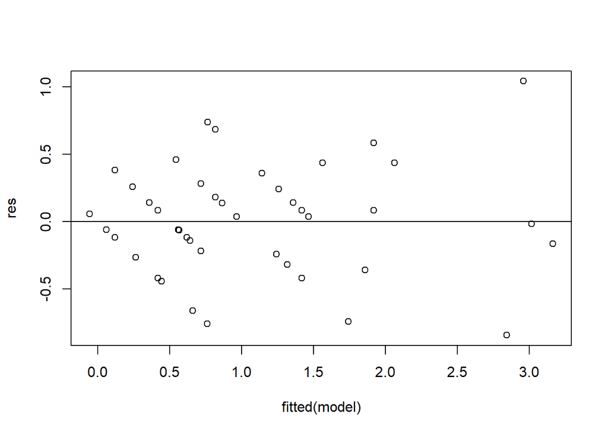

```r
res <- resid(model)

#produce residual vs. fitted plot
plot(fitted(model), res)

#add a horizontal line at 0
abline(0,0)
```

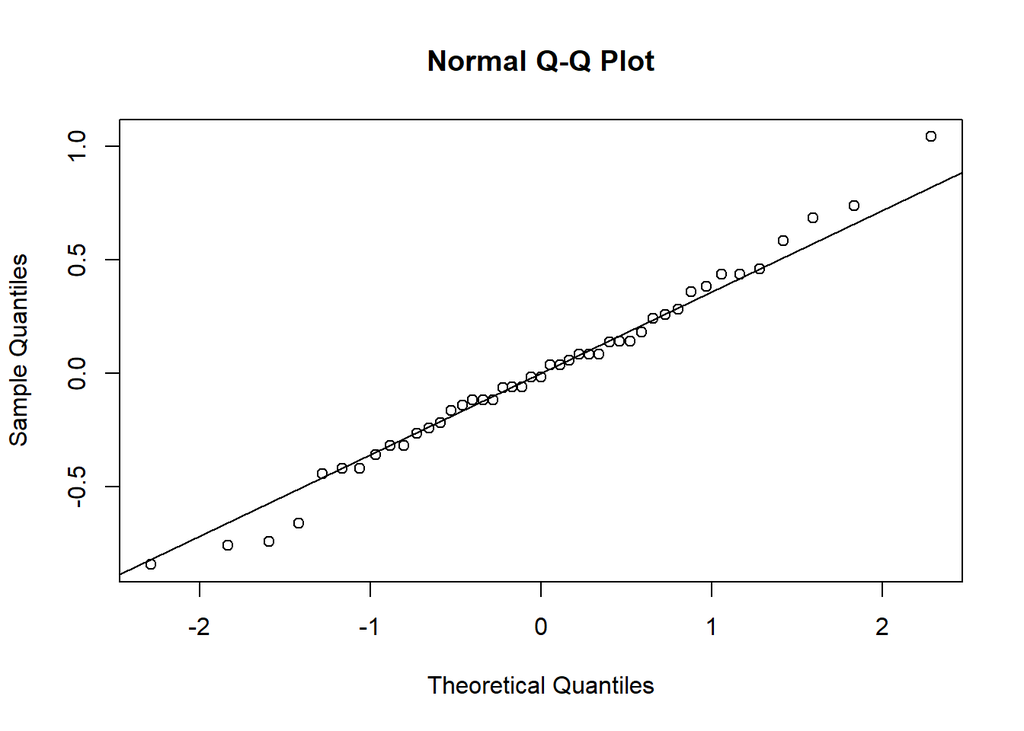

```r
#create Q-Q plot for residuals
qqnorm(res)

#add a straight diagonal line to the plot
qqline(res)
```

### iv. Sperm motility CASA (%)

```r
model <- lmer(sqrt(Percent_motile) ~ Treatment + (1|Male), data = Sperm_2025_1)
summary(model)
```

```
## Linear mixed model fit by REML ['lmerMod']
## Formula: sqrt(Percent_motile) ~ Treatment + (1 | Male)
##    Data: Sperm_2025_1
##
## REML criterion at convergence: 121.9
##
## Scaled residuals:
##     Min      1Q  Median      3Q     Max
## -1.9583 -0.4972  0.0073  0.5456  1.9927
##
## Random effects:
##  Groups   Name        Variance Std.Dev.
##  Male     (Intercept) 0.3336   0.5776
##  Residual             0.9901   0.9951
## Number of obs: 45, groups:  Male, 5
##
## Fixed effects:
##                   Estimate Std. Error t value
## (Intercept)         6.6447     0.5145  12.914
## TreatmentDMSO 10%  -4.4604     0.6293  -7.088
## TreatmentDMSO 15%  -4.5009     0.6293  -7.152
## TreatmentEG 10%    -3.4478     0.6293  -5.479
## TreatmentEG 15%    -4.2819     0.6293  -6.804
## TreatmentGly 10%   -2.5248     0.6293  -4.012
## TreatmentGly 15%   -2.9466     0.6293  -4.682
## TreatmentPG 10%    -5.2468     0.6293  -8.337
## TreatmentPG 15%    -5.7563     0.6293  -9.147
##
## Correlation of Fixed Effects:
##             (Intr) TDMSO10 TDMSO15 TEG10% TEG15% TrG10% TrG15% TPG10%
## TrtmDMSO10% -0.612
## TrtmDMSO15% -0.612  0.500
## TrtmntEG10% -0.612  0.500   0.500
## TrtmntEG15% -0.612  0.500   0.500   0.500
## TrtmntGl10% -0.612  0.500   0.500   0.500  0.500
## TrtmntGl15% -0.612  0.500   0.500   0.500  0.500  0.500
## TrtmntPG10% -0.612  0.500   0.500   0.500  0.500  0.500  0.500
## TrtmntPG15% -0.612  0.500   0.500   0.500  0.500  0.500  0.500  0.500
```

```r
car::Anova(model)
```

```
## Analysis of Deviance Table (Type II Wald chisquare tests)
##
## Response: sqrt(Percent_motile)
##            Chisq Df Pr(>Chisq)
## Treatment 120.59  8  < 2.2e-16 ***
## ---
## Signif. codes:  0 '***' 0.001 '**' 0.01 '*' 0.05 '.' 0.1 ' ' 1
```

Contrasts:

```r
emmeans(model, specs = pairwise ~ Treatment, type = "response", adjust = "none")
```

```
## $emmeans
##  Treatment response    SE   df lower.CL upper.CL
##  Control     44.152 6.838 23.9   31.164    59.40
##  DMSO 10%     4.771 2.248 23.9    1.259    10.54
##  DMSO 15%     4.596 2.206 23.9    1.170    10.28
##  EG 10%      10.220 3.290 23.9    4.557    18.14
##  EG 15%       5.583 2.432 23.9    1.691    11.73
##  Gly 10%     16.974 4.240 23.9    9.349    26.86
##  Gly 15%     13.676 3.806 23.9    6.948    22.66
##  PG 10%       1.954 1.439 23.9    0.113     6.05
##  PG 15%       0.789 0.914 23.9    0.000     3.81
##
## Degrees-of-freedom method: kenward-roger
## Confidence level used: 0.95
## Intervals are back-transformed from the sqrt scale
##
## $contrasts
##  contrast            estimate    SE df t.ratio p.value
##  Control - DMSO 10%    4.4604 0.629 32   7.088  <.0001
##  Control - DMSO 15%    4.5009 0.629 32   7.152  <.0001
##  Control - EG 10%      3.4478 0.629 32   5.479  <.0001
##  Control - EG 15%      4.2819 0.629 32   6.804  <.0001
##  Control - Gly 10%     2.5248 0.629 32   4.012  0.0003
##  Control - Gly 15%     2.9466 0.629 32   4.682  <.0001
##  Control - PG 10%      5.2468 0.629 32   8.337  <.0001
##  Control - PG 15%      5.7563 0.629 32   9.147  <.0001
##  DMSO 10% - DMSO 15%   0.0405 0.629 32   0.064  0.9491
##  DMSO 10% - EG 10%    -1.0127 0.629 32  -1.609  0.1174
##  DMSO 10% - EG 15%    -0.1785 0.629 32  -0.284  0.7785
##  DMSO 10% - Gly 10%   -1.9356 0.629 32  -3.076  0.0043
##  DMSO 10% - Gly 15%   -1.5139 0.629 32  -2.406  0.0221
##  DMSO 10% - PG 10%     0.7864 0.629 32   1.250  0.2205
##  DMSO 10% - PG 15%     1.2958 0.629 32   2.059  0.0477
##  DMSO 15% - EG 10%    -1.0531 0.629 32  -1.673  0.1040
##  DMSO 15% - EG 15%    -0.2190 0.629 32  -0.348  0.7301
##  DMSO 15% - Gly 10%   -1.9761 0.629 32  -3.140  0.0036
##  DMSO 15% - Gly 15%   -1.5544 0.629 32  -2.470  0.0190
##  DMSO 15% - PG 10%     0.7459 0.629 32   1.185  0.2446
##  DMSO 15% - PG 15%     1.2554 0.629 32   1.995  0.0546
##  EG 10% - EG 15%       0.8341 0.629 32   1.325  0.1944
##  EG 10% - Gly 10%     -0.9230 0.629 32  -1.467  0.1522
##  EG 10% - Gly 15%     -0.5012 0.629 32  -0.796  0.4316
##  EG 10% - PG 10%       1.7990 0.629 32   2.859  0.0074
##  EG 10% - PG 15%       2.3085 0.629 32   3.668  0.0009
##  EG 15% - Gly 10%     -1.7571 0.629 32  -2.792  0.0088
##  EG 15% - Gly 15%     -1.3354 0.629 32  -2.122  0.0417
##  EG 15% - PG 10%       0.9649 0.629 32   1.533  0.1350
##  EG 15% - PG 15%       1.4744 0.629 32   2.343  0.0255
##  Gly 10% - Gly 15%     0.4218 0.629 32   0.670  0.5076
##  Gly 10% - PG 10%      2.7220 0.629 32   4.325  0.0001
##  Gly 10% - PG 15%      3.2315 0.629 32   5.135  <.0001
##  Gly 15% - PG 10%      2.3003 0.629 32   3.655  0.0009
##  Gly 15% - PG 15%      2.8097 0.629 32   4.465  0.0001
##  PG 10% - PG 15%       0.5095 0.629 32   0.810  0.4242
##
## Note: contrasts are still on the sqrt scale
## Degrees-of-freedom method: kenward-roger
```

Check model assumptions:

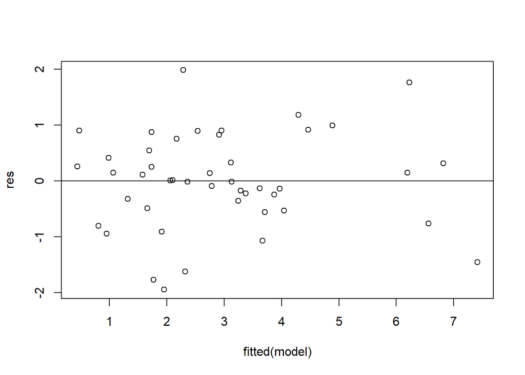

```r
res <- resid(model)

#produce residual vs. fitted plot
plot(fitted(model), res)

#add a horizontal line at 0
abline(0,0)
```

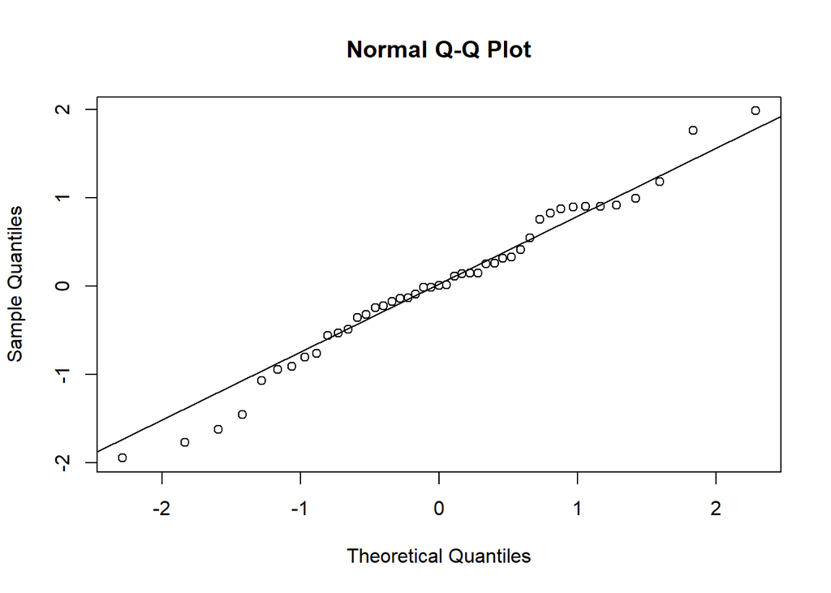

```r
#create Q-Q plot for residuals
qqnorm(res)

#add a straight diagonal line to the plot
qqline(res)
```

___________________________________________

# **4.** Experiment 3: CPA toxicity on germlings

## **4a)** Import data

```r
Counts_Toxicity <- read.csv("Data_cryo/Germling_Count_toxicity.csv")
Lengths_toxicity <- read.csv("Data_cryo/Germling_length_toxicity.csv")
```

## **4b)** Data structure and summary

### Germling counts

1. Check structure

```r
str(Counts_Toxicity)
```

```
## 'data.frame':    174 obs. of  13 variables:
##  $ Site           : chr  "South Cronulla" "South Cronulla" "South Cronulla" "South Cronulla" ...
##  $ DOB            : chr  "30/05/2024" "30/05/2024" "30/05/2024" "30/05/2024" ...
##  $ Age            : chr  "6 days " "6 days " "6 days " "6 days " ...
##  $ Female         : int  1 1 1 1 1 1 2 2 2 2 ...
##  $ Well.number    : int  1 5 6 2 3 4 2 1 5 6 ...
##  $ CPA            : chr  "EG" "PG" "Gly" "DMSO" ...
##  $ Concentration  : int  10 10 10 10 10 10 10 10 10 10 ...
##  $ Treatment      : chr  "EG 10%" "PG 10%" "Gly 10%" "DMSO 10%" ...
##  $ Date           : chr  "5/06/2024" "5/06/2024" "5/06/2024" "5/06/2024" ...
##  $ Day            : int  0 0 0 0 0 0 0 0 0 0 ...
##  $ Alive_germlings: int  33 41 32 38 42 56 32 14 30 25 ...
##  $ Attached       : int  0 0 0 0 0 0 0 0 0 0 ...
##  $ Starting_alive : int  33 41 32 38 42 56 32 14 30 25 ...
```

2. Separate experiment 3 and following trial (E3-v2)

```r
Counts_6 <- filter(Counts_Toxicity, Age == "6 days ")
Counts_7 <- filter(Counts_Toxicity, Age == "7 days")
```

3. Calculate mean by treatment and freezing rate for E3

```r
CountTox_percent6 <- Counts_6 %>%
  group_by (Treatment, Day, Female) %>%
  summarise(Percent_survival = ((Alive_germlings*100)/Starting_alive)) %>%
  filter(Percent_survival != "NaN")

CountTox_mean6 <- CountTox_percent6 %>%
  group_by (Treatment, Day) %>%
  summarise(Count_mean = mean(Percent_survival), n = n(), sd = sd(Percent_survival), se = sd/sqrt(n))
```

4. Calculate mean by treatment and freezing rate for E3-v2

```r
CountTox_percent7 <- Counts_7 %>%
  group_by (Treatment, Day, Female) %>%
  summarise(Percent_survival = ((Alive_germlings*100)/Starting_alive)) %>%
  filter(Percent_survival != "NaN")

CountTox_mean7 <- CountTox_percent7 %>%
  group_by (Treatment, Day) %>%
  summarise(Count_mean = mean(Percent_survival), n = n(), sd = sd(Percent_survival), se = sd/sqrt(n))
```

### Germling length

1. Check structure

```r
str(Lengths_toxicity)
```

```
## 'data.frame':    779 obs. of  16 variables:
##  $ Female       : int  4 2 1 1 1 1 10 1 2 4 ...
##  $ Well.number  : int  1 3 3 3 3 3 3 3 2 1 ...
##  $ CPA          : chr  "Control" "Control" "FSW" "FSW" ...
##  $ Concentration: int  NA NA NA NA NA NA 10 NA 10 NA ...
##  $ Treatment    : chr  "Control" "Control" "FSW" "FSW" ...
##  $ Site         : chr  "South Cronulla" "South Cronulla" "South Cronulla" "South Cronulla" ...
##  $ DOB          : chr  "5/30/2024" "5/30/2024" "5/30/2024" "5/30/2024" ...
##  $ Date         : chr  "6/18/2024" "6/12/2024" "6/12/2024" "6/18/2024" ...
##  $ Day          : int  14 7 7 14 14 7 14 14 14 14 ...
##  $ Photo        : chr  "F4_Control " "F2_Control0002" "F1_FSW0001" "F1_FSW0001" ...
##  $ Replicate    : int  4 10 7 7 9 9 1 5 9 3 ...
##  $ Length       : num  1.27 1.2 1.14 1.13 1.13 ...
##  $ Length_noriz : num  0.87 0.709 0.714 0.58 0.811 0.71 0.759 0.712 0.728 0.813 ...
##  $ Area         : num  0.62 0.103 0.124 0.116 0.14 0.122 0.112 0.112 0.091 0.109 ...
##  $ Shape        : chr  "Elongated " "Elongated " "Elongated " "Elongated " ...
##  $ Status       : chr  "Normal" "Normal" "Normal" "Normal" ...
```

2. Calculate mean value for each female

```r
Lengths_toxicity$Day <- as.factor(Lengths_toxicity$Day)
Lengths_tox <- Lengths_toxicity %>%
group_by (Treatment, Day, Female) %>%
summarise(Length = mean(Length_noriz), Area = mean(Area))
```

3. Calculate mean by treatment and freezing rate for E3

```r
LengthTox_mean <- Lengths_tox %>%
  group_by (Treatment, Day) %>%
  summarise(MeanLength = mean(Length),n = n(), sd_l = sd(Length), se_l = sd_l/sqrt(n), MeanArea = mean(Area),n = n(), sd_a = sd(Area), se_a = sd_a/sqrt(n))
```

## **4c)** Visualise patterns

### Germling counts

#### i. Survival plot E3

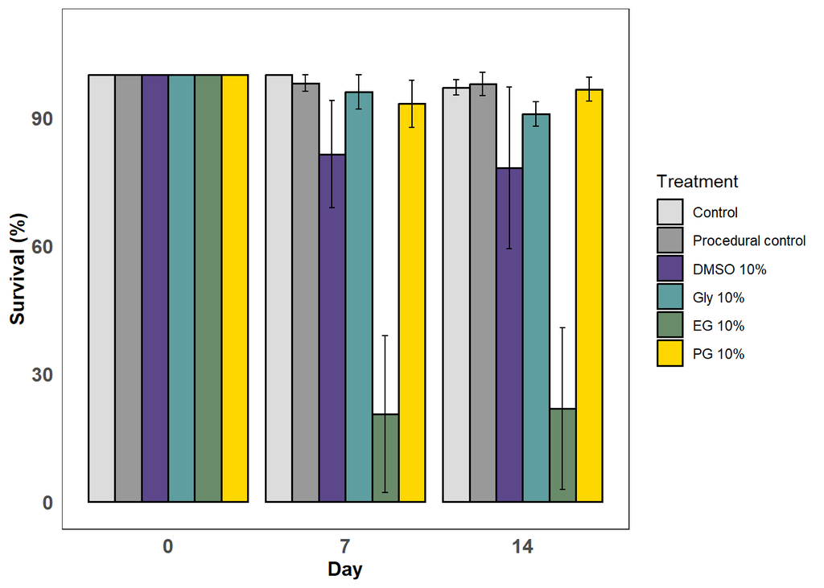

```r
CountTox_mean6 <- CountTox_mean6 %>%
  mutate(Treatment = if_else(
    Treatment == "FSW",
    "Procedural control",
    Treatment
  ))
CountTox_mean6$Treatment <- factor(CountTox_mean6$Treatment, levels = c("Control", "Procedural control", "DMSO 10%", "Gly 10%", "EG 10%","PG 10%"))


CountTox_mean6$Day <- as.factor(CountTox_mean6$Day)
Count_plot6 <- CountTox_mean6  %>%
filter(Day != "1") %>%
ggplot(aes(x= Day, y= Count_mean, fill = Treatment)) +
  geom_bar(stat="identity", color="black",
           position=position_dodge(), linewidth = 0.6) +
 geom_errorbar(aes(ymin=Count_mean-se, ymax=Count_mean+se), width=.2, position=position_dodge(0.9)) +
Theme1 +
labs( y="Survival (%)", x="Day")   +
  scale_fill_viridis(discrete = TRUE) +
theme(strip.text.x = element_text(size = 12)) + scale_fill_manual(
    values = c("DMSO 10%" = "mediumpurple4", "EG 10%" = "darkseagreen4","Gly 10%" = "cadetblue","PG 10%" = "gold","Control" = "gainsboro", "Procedural control" = "gray60")) + scale_y_continuous(limit = c(-1, 110))
Count_plot6
```

```r
ggsave("E3_surv.jpeg", width = 16, height = 7.5, units = "cm")
```

#### i. Survival plot E3_v2

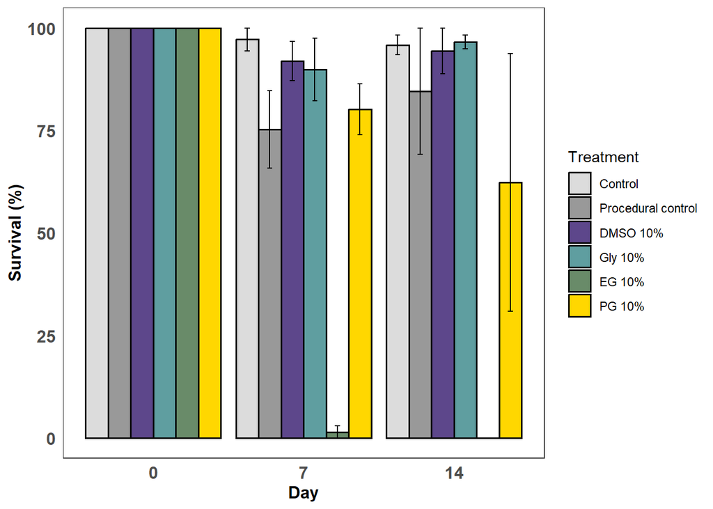

```r
CountTox_mean7 <- CountTox_mean7 %>%
  mutate(Treatment = if_else(
    Treatment == "FSW",
    "Procedural control",
    Treatment
  ))
CountTox_mean7$Treatment <- factor(CountTox_mean7$Treatment, levels = c("Control", "Procedural control", "DMSO 10%", "Gly 10%", "EG 10%","PG 10%"))

CountTox_mean7$Day <- as.factor(CountTox_mean7$Day)
Count_plot7 <- CountTox_mean7  %>%
ggplot(aes(x= Day, y= Count_mean, fill = Treatment)) +
  geom_bar(stat="identity", color="black",
           position=position_dodge(), linewidth = 0.6) +
 geom_errorbar(aes(ymin=Count_mean-se, ymax=Count_mean+se), width=.2, position=position_dodge(0.9)) +
Theme1 +
labs( y="Survival (%)", x="Day")   +
  scale_fill_viridis(discrete = TRUE) +
theme(strip.text.x = element_text(size = 12)) + scale_fill_manual(
    values = c("DMSO 10%" = "mediumpurple4", "EG 10%" = "darkseagreen4","Gly 10%" = "cadetblue","PG 10%" = "gold","Control" = "gainsboro", "Procedural control" = "gray60"))
Count_plot7
```

```r
ggsave("E3v2_surv.jpeg", width = 16, height = 8, units = "cm")
```

### Germling length

#### i. Length plot E3

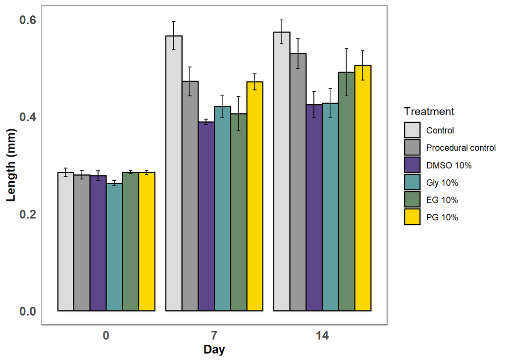

```r
LengthTox_mean <- LengthTox_mean %>%
  mutate(Treatment = if_else(
    Treatment == "FSW",
    "Procedural control",
    Treatment
  ))
LengthTox_mean$Treatment <- factor(LengthTox_mean$Treatment, levels = c("Control", "Procedural control", "DMSO 10%", "Gly 10%", "EG 10%","PG 10%"))


plot6 <- LengthTox_mean  %>%
ggplot(aes(x= Day, y= MeanLength, fill = Treatment)) +
  geom_bar(stat="identity", color="black",
           position=position_dodge(), linewidth = 0.6) +
 geom_errorbar(aes(ymin=MeanLength-se_l, ymax=MeanLength+se_l), width=.2, position=position_dodge(0.9)) +
Theme1 +
labs( y="Length (mm)", x="Day")   +
  scale_fill_viridis(discrete = TRUE) +
theme(strip.text.x = element_text(size = 12)) + scale_fill_manual(
    values = c("DMSO 10%" = "mediumpurple4", "EG 10%" = "darkseagreen4","Gly 10%" = "cadetblue","PG 10%" = "gold","Control" = "gainsboro", "Procedural control" = "gray60"))
plot6
```

```r
ggsave("E3_length.jpeg", width = 16, height = 7.5, units = "cm")
```

#### ii. Area plot E3

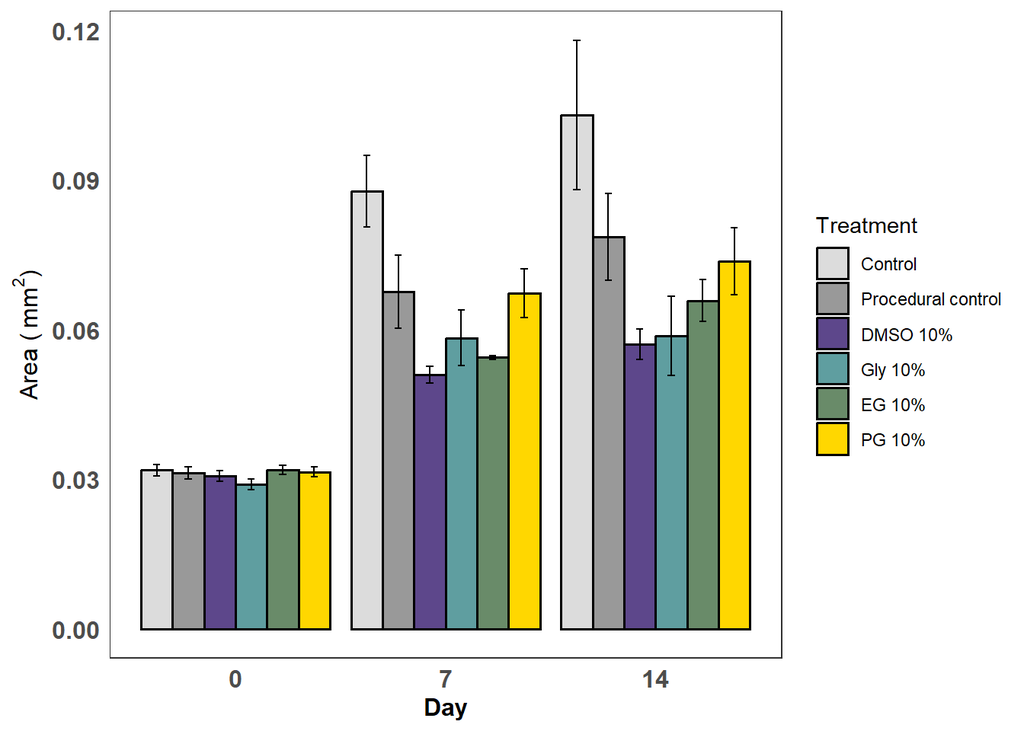

```r
plot6 <- LengthTox_mean  %>%
ggplot(aes(x= Day, y= MeanArea, fill = Treatment)) +
  geom_bar(stat="identity", color="black",
           position=position_dodge(), linewidth = 0.6) +
 geom_errorbar(aes(ymin=MeanArea-se_a, ymax=MeanArea+se_a), width=.2, position=position_dodge(0.9)) +
Theme1 +
labs( y="Area ("~mm^2*")", x="Day")   +
  scale_fill_viridis(discrete = TRUE) +
theme(strip.text.x = element_text(size = 12)) + scale_fill_manual(
    values = c("DMSO 10%" = "mediumpurple4", "EG 10%" = "darkseagreen4","Gly 10%" = "cadetblue","PG 10%" = "gold","Control" = "gainsboro", "Procedural control" = "gray60"))
plot6
```

```r
ggsave("E3_area.jpeg", width = 16, height = 7.5, units = "cm")
```